# Badanie kolejności oglądania eksponatów przez odwiedzających wystawę Regeneracja

Izabela Lis, Aleksandra Paluszyńska

27 kwietnia 2016

Poza pracą zespołową szczególnym wkładem autorek w było:

- przygotowanie mapek wystawy (Izabela Lis),
- programowanie w R (Aleksandra Paluszyńska).

## Pytania badawcze

Nasza analiza ma na celu odpowiedzenie na następujące pytania badawcze.

#### 1. Z czego wynika popularność poszczególnych eksponatów? Czy popularne eskponaty zawsze są ciekawe?

Na to pytanie odpowiemy we wstępnej analizie eksploracyjnej przyglądając się rozkładom czasów interakcji z eksponatami oraz częstościom wizyt w stacjach jako pierwszych, ostatnich i ogółem. Sprawdzimy też, czy odwiedzenie pewnych stacji powoduje wzrost lub spadek średniego czasu interakcji z eksponatami podczas zwiedzania wystawy.

#### 2. Którzy odwiedzający oglądają wiele eksponatów, a którzy poświęcają im więcej czasu?

Na pierwszą część pytania odpowiemy sobie za pomocą regresji logistycznej objaśniającej fakt obejrzenia co najmniej 10 eksponatów - będzie ona wstępem do ograniczenia analizy całych ścieżek tylko do tej grupy. Na drugą część pytania odpowiemy we wstępnej eksploracji danych za pomocą regresji liniowej objaśniającej średni czas interakcji z eksponatami.

#### 3. Jakie ścieżki są typowe i co wpływa na ich powstawanie?

Na to pytanie odpowiemy na dwa sposoby: najpierw rozpatrzymy podścieżki analizując częstości ich występowania oraz konstruując reguły decyzyjne, a następnie rozpatrzymy całe ścieżki wśród osób, które odwiedziły co najmniej 10 stacji. W tej podgrupie dokonamy klasteryzacji i scharakteryzujemy otrzymane grupy odwiedzających.

#### 4. Jak architektura wystawy wpływa na sposób poruszania się odwiedzających po niej?

Na to pytanie będziemy odpowiadać stopniowo, począwszy od porównania częstości odwiedzin danej stacji jako pierwszej lub ostatniej z rozkładem czasu interakcji z nią, poprzez przyjrzenie się popularnym podścieżkom aż po rozpatrzenie całych ścieżek.

#### 5. Która strefa cieszy się największą popularnością wśród odwiedzających i dlaczego?

Na to pytanie odpowiemy w dwóch etapach: najpierw za pomocą reguł asocjacji stwierdzimy czy popularne podścieżki były w obrębie stref, czy może pomiędzy nimi, a następnie za pomocą metody składowych głównych zastosowanej do klastrów stwierdzimy, czy stacje, których odwiedzenie bądź nieodwiedzenie, różnicuje odwiedzających są rozłożone w różnych strefach.

## Wykorzystane dane

W naszej analizie ograniczyłyśmy się do danych ze stycznia - na wstępnym etapie eksploracji danych nie zauważyłyśmy różnicy pomiędzy zachowaniem odwiedzających w poszczególnych miesiącach, a pełen zbiór okazał się dość problematyczny dla naszych komputerów.

W tym miejscu wczytamy przygotowane uprzednio dane (opisany kod przetwarzający wyjściowy zbiór znajduje się w załączniku).

```r
setwd("~/UW/Statystyka_II/Projekt1")
load("faza3_dane.rda") # wyjściowa ramka danych w formie długiej
str(data_both) # struktura naszej ramki danych
```

```
## 'data.frame':    214083 obs. of  8 variables:
##  $ odwiedzajacy     : chr  "795449" "795453" "795453" "795453" ...
##  $ stacja           : Factor w/ 59 levels "cnk02a","cnk02b",..: 2 6 7 13 21 48 25 53 44 22 ...
##  $ nr_interakcji    : num  1 1 1 1 1 1 1 1 1 1 ...
##  $ data_wejscia     : POSIXct, format: "2012-01-01 09:00:54" "2012-01-03 09:32:51" ...
##  $ data_wyjscia     : POSIXct, format: "2012-01-01 09:00:54" "2012-01-03 09:34:14" ...
##  $ czas_interakcji  : num  0 83 109 51 5 18 335 22 89 11 ...
##  $ przejscie        : chr  NA NA "cnk07->cnk09" "cnk09->cnk16" ...
##  $ poprzednia_stacja: chr  NA NA "cnk07" "cnk09" ...
```

```r
load("faza3_wizyty.rda") # dane w postaci szerokiej wskazujące na interakcję z danym eksponatem
load("faza3_przejscia.rda") # dane w postaci szerokiej wskazujące na odbyte przejścia między eksponatami
load("faza3_czasy.rda") # dane w postaci szerokiej z czasami interakcji z danym eksponatem
```

W naszej analizie będziemy często korzystać z macierzy wskazującej na interakcję z danym eksponatem oraz z macierzy wskazującej na odbyte przejścia między eksponatami. Pierwszą z nich nazywamy macierzą wizyt: kolumny odpowiadają stacjom, wiersze odwiedzającym, a wartość równa jeden oznacza, że dany odwiedzający obejrzał dany eksponat. Drugą z nich nazywamy macierzą przejść: kolumny odpowiadają bilateralnym przejściom pomiędzy eksponatami, wiersze odwiedzającym, a wartość równa jeden oznacza, że dany odwiedzający wykonał dane przejście pomiędzy stacjami.

Analiza w oparciu o obie macierze ma za zadanie nie tylko otrzymanie dodatkowych wyników, ale również porównanie obu podejść: w pierwszym zupełnie tracimy informację o kolejności zwiedzanych eksponatów, a w drugim znacznie powiększamy rozmiar macierzy (co utrudnia obliczenia).

W analizie skorzystamy z następujących pakietów.

```r
library(tidyr) # przekształcanie danych do postaci szerokiej
library(arules) # tworzenie reguł asocjacji
library(ggplot2) # tworzenie wykresów
library(cluster) # klasteryzacja
library(vegan) # pozwala na obliczanie macierzy odległości metodą Jaccarda
library(arulesViz) # pozwala na wizualizację reguł asocjacji
library(caret) # pozwala wyznaczyć macierz klasyfikacji dla modelu logitowego
library(e1071) # potrzebne do pakietu caret
library(devtools) # potrzebne do pakietu factoextra
library(factoextra) # pozwala wyznaczyć sylwetki dla klastrów
library(vegan) # pozwala obliczyć macierz odległości metodą Jaccarda
library(MASS) # do rzutowania na dwa wymiary
```

## Wstępna eksploracja danych

Na początku wykonamy podstawową eksplorację danych obliczając statystyki opisowe dla takich zmiennych jak czas interakcji z poszczególnymi eksponatami czy przejść pomiędzy nimi. Niektóre zależności zweryfikujemy obliczając współczynniki korelacji czy konstruując model regresji liniowej. Ta część analizy pozwoli nam zorientować się w danych i dowiedzieć, na jakie pytania mogą one udzielić odpowiedzi. Dodatkowe wyniki z tego etapu analizy znajdują się w załączniku.

### Czasy interakcji

Przy szukaniu odpowiedzi na pierwsze pytanie analizować będziemy rozkład czasu interakcji z daną stacją biorąc pod uwagę jej popularność czyli liczbę interakcji przeprowadzonych z tą stacją.

#### Rozkład czasów interakcji dla najpopularniejszych eksponatów

Najpierw przyjrzymy się rozkładowi czasu interakcji z eksponatem wśród kilku najczęściej odwiedzanych maszynach.

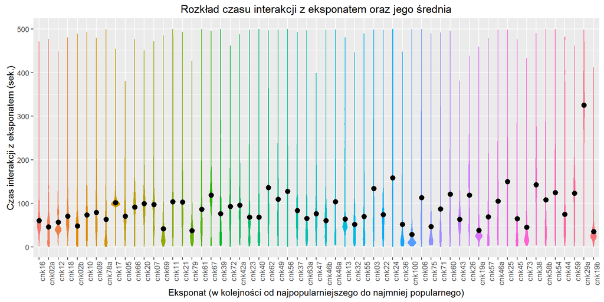

```r
temp <- as.data.frame(table(data_both[, "stacja"])) # tabela częstości odwiedzania wszystkich stacji
najpopularniejsze <- head(temp[order(temp$Freq, decreasing = TRUE), "Var1"], n=5) # 5 najczęściej odwiedzanych
data_najp <- within(data_both, stacja <- factor(stacja, levels=names(sort(table(stacja), decreasing=TRUE)))) # sortujemy stacje od najpopularniejszej w dół
ggplot(data_najp, aes(stacja, czas_interakcji, color = stacja, fill = stacja)) + theme(legend.position="none") + geom_violin() + ylim(1,500) + xlab("Eksponat (w kolejności od najpopularniejszego do najmniej popularnego)") + ylab("Czas interakcji z eksponatem (sek.)") + theme(axis.text.x=element_text(angle = 90, hjust = 1)) + stat_summary(fun.data = "mean_cl_boot", colour = "black", size = 0.5) + ggtitle("Rozkład czasu interakcji z eksponatem oraz jego średnia")
```

Na powyższym wykresie widać, że średni czas interakcji (oznaczony czarną kropką) wahał się pomiędzy 50, a 150 sekundami z nielicznymi wyjątkami. Wyraźnie odstaje pod tym względem jedynie stacja **cnk29a**, której atrakcją jest rysujący robot - średni czas interakcji wyniósł w tym przypadku ponad 5 minut, przy czym cała masa rozkładu prawdopodobieństwa znajduje się w tych okolicach. Jeśli przyjmiemy czas interakcji z eksponatem za miarę jego atrakcyjności (jeśli eksponat jest nieciekawy, to odwiedzający może zrezygnować z interakcji), to można uznać eksponat **cnk29a** za ciekawy, chyba, że czas interakcji jest w jej przypadku inaczej mierzony (np. kiedy robot skończy rysować, a nie kiedy odwiedzający przestanie to oglądać).

Z drugiej strony, na wykresie wyraźnie wyłaniają się dwa rodzaje stacji - takie, dla których duża część masy rozkładu znajduje się blisko zera (dużo odwiedzających przerywało interakcję w pierwszych jej sekundach) oraz takie, dla których to nie jest prawda. W szczególności, stacje **cnk02a**, **cnk02b** oraz **cnk78a**, należące do najpopularniejszych, możemy zaklasyfikować do tej pierwszej grupy, a więc możemy je podejrzewać o bycie nieciekawymi.

W celu rozwinięcia tematu przerywania interakcji przez odwiedzających na poniższym wykresie przedstawiamy procent wszystkich odwiedzających daną stację osób rezygnuje z interakcji w jej pierwszych 10 sekundach.

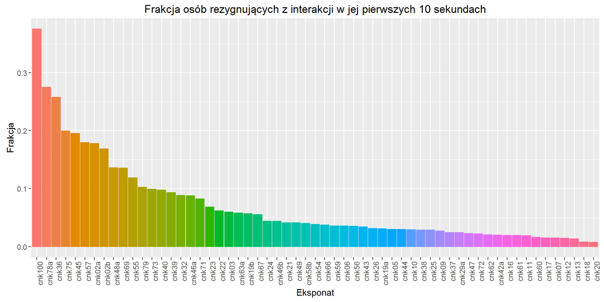

```r
temp[,3:4] <- as.data.frame(table((subset(data_both,czas_interakcji<=10))[,"stacja"])) # liczba odwiedzających, która zrezygnowała w pierwszych 10 sekundach interakcji
temp$procent <- temp[,4]/temp[,2]
temp <- within(temp, Var1 <- factor(Var1, levels=temp[order(temp$procent, decreasing = TRUE), "Var1"]))
ggplot(temp, aes(Var1, procent, color = Var1, fill = Var1)) + geom_bar(stat = "identity")+ ylab("Frakcja")  + xlab("Eksponat") + theme(legend.position="none") + ggtitle("Frakcja osób rezygnujących z interakcji w jej pierwszych 10 sekundach") + theme(axis.text.x=element_text(angle = 90, hjust = 1))
```

Na wykresie widać, że wspomniane wcześniej stacje **cnk02a**, **cnk02b** oraz **cnk78a** znajdują się w pierwszej dziesiątce pod względem frakcji odwiedzających przerywających interakcję w pierwszych jej sekundach (ponad 15%). W analizie podścieżek odpowiemy na nasuwające się pytanie: skąd bierze się tak wysoka popularność tych stacji skoro odwiedzający tak szybko rezygnują z interakcji z nimi?

### Liczba interakcji z danym eksponatem

Teraz zastanowimy się, dlaczego niektóre eksponaty są odwiedzane wielokrotnie przez tych samych odwiedzających - czy są one po prostu częściej odwiedzane (popularniejsze)?

Najpierw wyodrębnimy 10 eksponatów, z którymi najwięcej odwiedzających przeprowadza więcej niż jedną interakcję (możemy podejrzewać, że są one wyjątkowo ciekawe), a następnie sprawdzimy ile osób wykonało daną liczbę interakcji (patrzymy na wszystkie interakcje oprócz pierwszej).

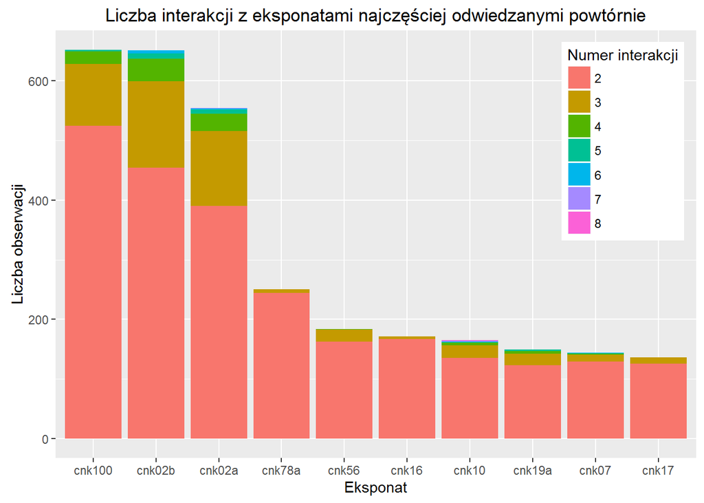

```r
# tabelka liczebności powtórnych odwiedzin według stacji
temp1 <- as.data.frame(table(data_both[data_both$nr_interakcji > 1, "stacja"]))
# wybieramy obserwacje dotyczące powtórnych odwiedzin 10 stacji, które najczęściej odwiedzano powtórnie
temp2 <- subset(data_both[data_both$nr_interakcji > 1,], stacja %in% tail(temp1[order(temp1$Freq), "Var1"], n=10))
# sortujemy stacje malejąco względem liczby obserwacji
temp2 <- within(temp2, stacja <- factor(stacja, levels=names(sort(table(stacja), decreasing=TRUE))))
ggplot(temp2, aes(stacja, fill = factor(nr_interakcji))) + geom_bar() + ylab("Liczba obserwacji") + xlab("Eksponat") + theme(legend.justification=c(1,1), legend.position=c(1,1)) + guides(fill=guide_legend(title="Numer interakcji")) + ggtitle("Liczba interakcji z eksponatami najczęściej odwiedzanymi powtórnie")
```

Na wykresie widać, że **cnk100**, **cnk02b** oraz **cnk02a** są głównymi eksponatami, z którymi odwiedzający przeprowadzają powtórne interakcje, a więc warto poświęcić im więcej uwagi. Z poprzednich rozważań wiemy, że są to również eksponaty, dla których wiele interakcji trwało zaledwie kilka sekund co sugeruje, że odwiedzający z jakiś powodów (np. tłok, osoby czekające w kolejce?) przerywali interakcję, aby później odbyć ją powtórnie.

W załączniku porównałyśmy również listę najpopularniejszych eksponatów ogólnie z listą najpopularniejszych eksponatów pod względem powtórnych odwiedzin i stwierdziłyśmy, że są one dość silnie skorelowane.

### Najczęstsze początki i końce odwiedzin

Aby znaleźć odpowiedź na pytanie dotyczące czynników wpływających na popularność danej stacji, stworzyłyśmy mapkę z najczęściej oraz najrzadziej odwiedzanymi stacjami oraz ze stacjami i przejściami, które były najczęściej wykonywane jako pierwsze lub ostatnie.

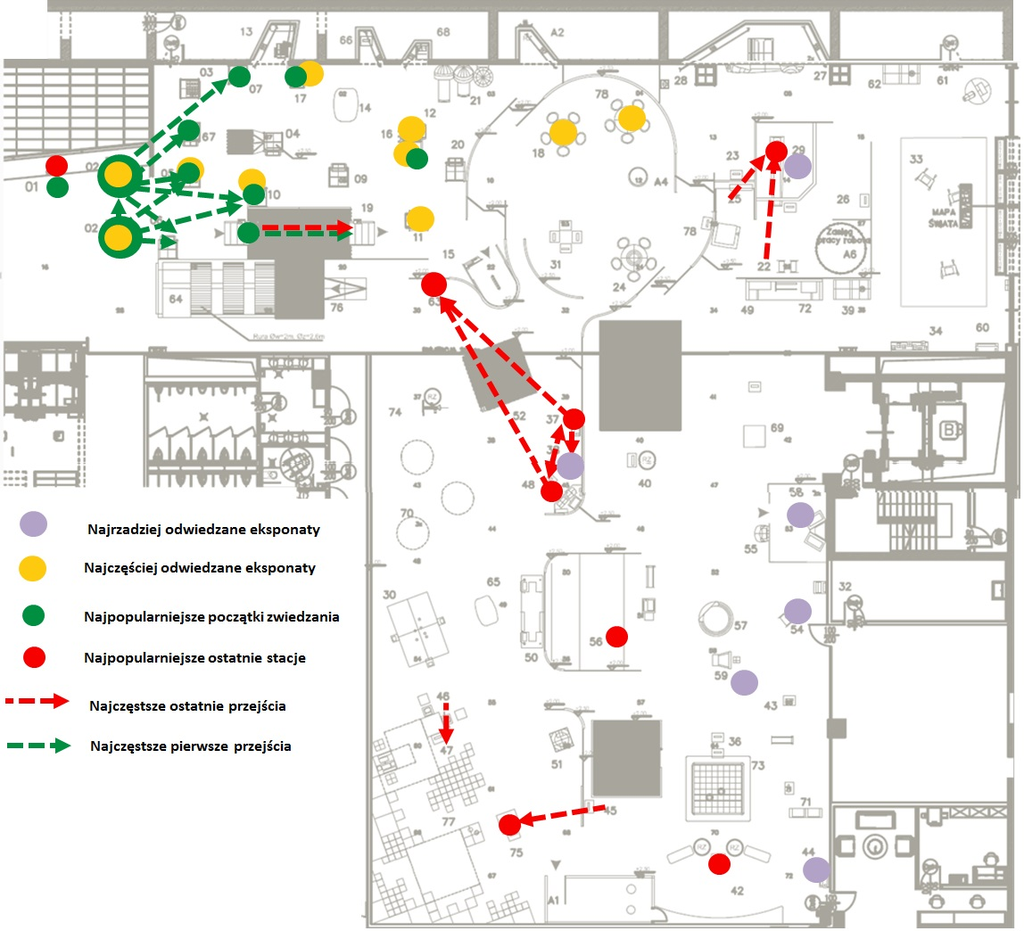

Na mapie widać, że aż 8 z 10 najbardziej popularnych stacji znajduje się w strefie pierwszej zaraz przy wejściu. Dodatkowo, aż 6 z nich pokrywa się ze stacjami, które są najczęściej odwiedzane jako pierwsze. Może zatem twierdzić, że najczęściej odwiedzane stacje w znacznej mierze zawdzięczają swoją popularność dobremu ułożeniu na planie galerii. W analizie podścieżek zobaczymy również, że pozostałe dwie stacje zaliczane do najbardziej popularnych (**cnk18** oraz **cnk78**) swoją wysoką popularność również zawdzięczają dobremu umiejscowieniu. Nie są co prawda umieszczone na początku galerii, ale w ich okolicach przechodzą najpopularniejsze podścieżki, zarówno długości 2, 3 jak i 4.

Warto również zwrócić uwagę na stacje najczęściej odwiedzane jako ostatnie - należy do nich **cnk29a**, która ma wyjątkowo wysoki średni czas interakcji, co pozwala podejrzewać, że choć stacja jest ciekawa, odwiedzający kończą po niej swoje zwiedzanie ze względu na zmęczenie lub ograniczenie czasowe. Z kolei stacje **cnk63**, **cnk37** oraz **cnk48** są położone przy końcu wystawy, a więc stanowią naturalny jej koniec.

Powyższa analiza pozwala nam twierdzić, że popularność konkretnego eksponatu w głównej mierze zależy od tego w jakim miejscu galerii jest on ustawiony. Dodatkowo, najpopularniejsze stacje często nie są wcale najciekawsze, jeśli ciekawość stacji mierzymy czasem interakcji z nią.

## Analiza podścieżek

### Najczęstrze podścieżki o długości czterech eksponatów

Na początek wyróżniłyśmy dziesięć najczęściej występujących podścieżek o długości trzech i czterech eksponatów (obliczenia znajdują się w załączniku). Przedstawiłyśmy je na poniższej mapce.

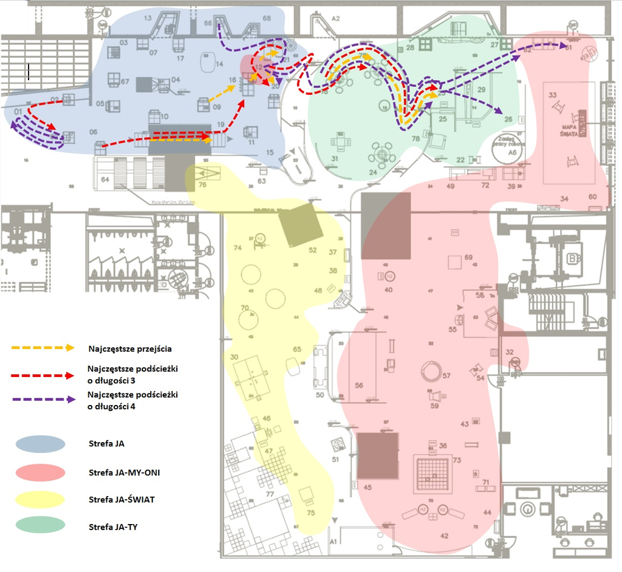

Na mapce widać, że najpopularniejsze podścieżki przebiegają przez dom strachów oraz stacje **cnk18** i **cnk78a** w strefie JA-TY. Podścieżki przebiegające przez dom strachów nie są interesujące, gdyż stacja **cnk19a** (wejście do domu strachów) wymusza wizytę w stacji **cnk19b** (wyjście z domu strachów).

### Reguły asocjacji

Za pomocą reguł asocjacji zidentyfikujemy często oglądane grupy eksponatów oraz często odbywane zestawy przejść pomiędzy eksponatami (możemy interpretować je jako uogólnione podścieżki - odwiedzający wykonał dany zestaw przejść, ale niekoniejcznie jedne po drugich).

#### Wykorzystanie macierzy wskazującej eksponaty

```r
# Tworzymy macierz wskazującą na odwiedzone stacje
wizyty_logi <- wizyty_w[,-1] > 0 # zaminiamy macierz na taką o wartościach logicznych
wizyty_logi <- wizyty_logi[, !(colnames(wizyty_logi)) %in% "cnk19b"] # wywalamy wyjście z tunelu strachów (wystarczy wejście)
trans_wizyty <- as(wizyty_logi, "transactions") # zamieniamy na macierz transakcji
# tworzymy reguły asocjacji
rule1 <- apriori(trans_wizyty, parameter = list(supp = 0.015), control = list(verbose = FALSE))
summary(rule1)
```

```
## set of 106 rules
##
## rule length distribution (lhs + rhs):sizes
##  4  5  6
##  1 94 11
##
##    Min. 1st Qu.  Median    Mean 3rd Qu.    Max.
##   4.000   5.000   5.000   5.094   5.000   6.000
##
## summary of quality measures:
##     support          confidence          lift
##  Min.   :0.01502   Min.   :0.8000   Min.   :2.717
##  1st Qu.:0.01562   1st Qu.:0.8069   1st Qu.:3.259
##  Median :0.01667   Median :0.8150   Median :3.295
##  Mean   :0.01707   Mean   :0.8190   Mean   :3.242
##  3rd Qu.:0.01795   3rd Qu.:0.8280   3rd Qu.:3.353
##  Max.   :0.02320   Max.   :0.8676   Max.   :3.514
##
## mining info:
##          data ntransactions support confidence
##  trans_wizyty         23963   0.015        0.8
```

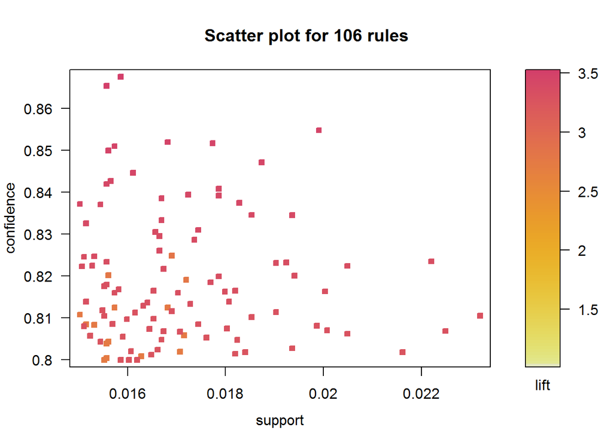

```r
plot(rule1)
```

Powyższa analiza pozwala nam wnioskować, że nie ma szczególnych zależności pomiędzy poszczególnymi eksponatami i odwiedzający bardzo różnie poruszają się pomiędzy stacjami.

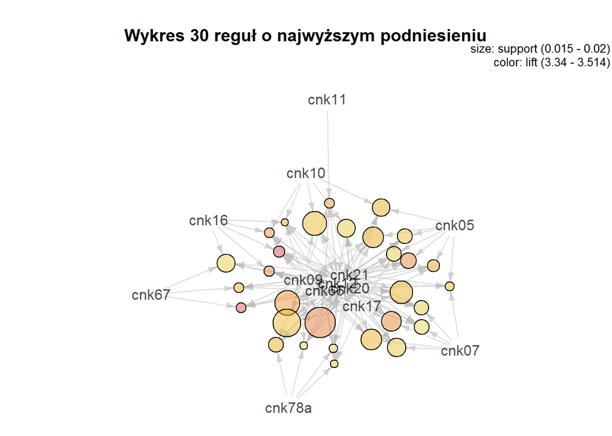

```r
plot(head(sort(rule1, by="lift"), n=30), method="graph", main="Wykres 30 reguł o najwyższym podniesieniu")
```

Na powyższym wykresie przedstawiamy reguły decyzyjne o najwyższym podniesieniu - są one skoncentrowane wokół kilku stacji ze strefy JA. W celu lepszego zrozumienia znaczenia zidentyfikowanych reguł asocjacji w dalszej analizie przedstawiamy dziesięć reguł o najwyższym podniesieniu na mapce wystawy.

#### Wykorzystanie macierzy wskazującej przejścia między eksponatami

Powyższa analiza pozwoliła na zidentyfikowanie stacji, które często współwystępują na trasie odwiedzin, jednak nie uwzględniła kolejności ich odwiedzania. Uwzględniamy ją przeprowadzając analogiczną analizę dla macierzy wskazującej bilateralne przejścia pomiędzy stacjami (tym razem usuwamy przejście przez tunel strachów).

```r
# Tworzymy macierz wskazującą na odbyte przejścia pomiędzy dwoma stacjami
przejscia_logi <- przejscia_w[,-1] > 0 # zaminiamy macierz na taką o wartościach logicznych
przejscia_logi <- przejscia_logi[, !(colnames(przejscia_logi)) %in% "cnk19a->cnk19b"] # wywalamy przejście przez tunel strachów
trans_przejscia <- as(przejscia_logi, "transactions") # zamieniamy na macierz transakcji
# tworzymy reguły asocjacji
rule2 <- apriori(trans_przejscia, parameter = list(supp = 0.001), control = list(verbose = FALSE))
# plot(head(sort(rule2, by = "lift"), n=20), method = "graph") # wykres w załączniku
summary(rule2)
```

```
## set of 40 rules
##
## rule length distribution (lhs + rhs):sizes
##  3  4
## 34  6
##
##    Min. 1st Qu.  Median    Mean 3rd Qu.    Max.
##    3.00    3.00    3.00    3.15    3.00    4.00
##
## summary of quality measures:
##     support           confidence          lift
##  Min.   :0.001022   Min.   :0.8043   Min.   :11.57
##  1st Qu.:0.001115   1st Qu.:0.8433   1st Qu.:17.62
##  Median :0.001277   Median :0.8685   Median :23.80
##  Mean   :0.001566   Mean   :0.8807   Mean   :29.64
##  3rd Qu.:0.001811   3rd Qu.:0.9149   3rd Qu.:39.23
##  Max.   :0.003762   Max.   :0.9615   Max.   :70.42
##
## mining info:
##             data ntransactions support confidence
##  trans_przejscia         21531   0.001        0.8
```

Wykres przedstawiający 10 najlepszych reguł asocjacji znajduje się w załączniku - tym razem reguły nie są ze sobą zbytnio powiązane i szczególnie ciekawe jest przedstawienie ich na mapce, gdyż w większości przypadków jedna reguła dotyczy trzech bilateralnych przejść, które mają wspólne końce.

#### Reguły asocjacji na mapie

Poniżej przedstawiamy kilka reguł o najwyższym podniesieniu zarówno na podstawie analizy macierzy wizyt (linia przerywana), jak i na podstawie analizy macierzy przejść (linia ciągła).

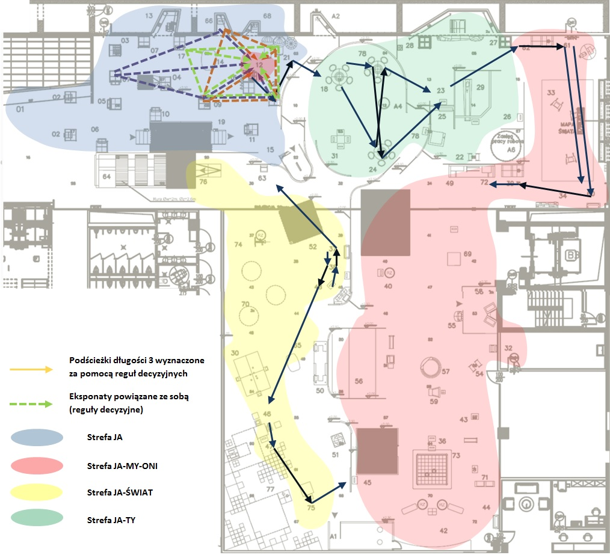

Na powyższej mapce widać, że wybrane reguły asocjacji dotyczące wizyt w stacjach są skoncentrowane wokół stacji **cnk16** oraz **cnk12**, co wynika prawdopodobnie z dużego zagęszczenia stacji w tamtym rejonie. Z drugiej strony, reguły dotyczące przejść wyraźnie układają się w (uogólnione) podścieżki - zupełnie inne, niż te wyróżnione na podstawie częstości (tutaj nie musi być zachowana kolejność). Po raz kolejny wyróżnia się tutaj grupa stacji znajdująca się w owalu strefy JA-TY. Nowością są natomiast prześcia w strefie JA-ŚWIAT, które odbywają się w “odwrotną” stronę.

## Analiza kompletnych ścieżek

W tej części będziemy analizować kompletne ścieżki zwiedzania wystawy przez odwiedzających. Wyodrębnimy również grupy odwiedzających, którzy są podobni do siebie ze względu na sposób poruszania się po wystawie, co pozwoli dostosować ją do ich potrzeb.

W poprzedniej części analizowaliśmy krótkie podścieżki, stąd teraz zajmiemy się długimi ścieżkami. W tym celu usuniemy ze zbioru odwiedzających, którzy obejrzeli niewiele eksponatów, powiedzmy mniej niż 10.

### Kiedy odwiedzający odwiedzają co najmniej 10 eksponatów?

Najpierw zastanowimy się, czym charakteryzują się odwiedzający, którzy widzieli co najmniej 10 eksponatów: tworzymy zmienną binarną wskazującą na odwiedzenie takiej liczby eksponatów i obliczamy częstości wystąpienia obu kategorii. Dodajemy również potrzebne w dalszej analizie zmienne wskazujące na godzinę i dzień tygodnia wejścia na wystawę.

```r
sredni_czas <- aggregate(czas_interakcji ~ odwiedzajacy, data_both, mean) # konstruujemy zmienną objaśnianą do modelu regresji logistycznej
dane2 <- merge(wizyty_w, sredni_czas, by = "odwiedzajacy")

data_both$godzina <- format(data_both$data_wejscia, "%H")
data_both$godzina <- as.numeric(data_both$godzina) # przekształcamy do zmiennej jakościowej
godzina_wejscia <- aggregate(godzina ~ odwiedzajacy, data_both, min) # wybieramy jedną obserwację dla każdego
godzina_wejscia$godzina <- as.factor(godzina_wejscia$godzina) # przerabiamy na zmienną jakościową

# Tworzymy zmienną dzień tygodnia
data_both$dzien <- as.factor(weekdays(data_both$data_wejscia))
data_both <- subset(data_both, dzien!="poniedziałek") # wywalamy poniedziałek bo wtedy jest nieczynne
data_both$dzien <- as.numeric(data_both$dzien) # zamieniamy na numeryczną do agregacji
dzien_tygodnia <- aggregate(dzien ~ odwiedzajacy, data_both, min) # wybieramy jedną obserwację dla każdego

# Scalamy dane
dane2_1 <- merge(dane2, godzina_wejscia, by = "odwiedzajacy")
dane2 <- merge(dane2_1, dzien_tygodnia, by = "odwiedzajacy")
dane2$dzien <- factor(dane2$dzien, levels = c(7,6,1,3,5,2), labels = c("wtorek", "środa", "czwartek", "piątek", "sobota", "niedziela")) # z powrotem nadajemy formaty

table(dane2$godzina) # liczba obserwacji dla poszczególnych godzin wejścia na wystawę
```

```
##
##    7    8    9   10   11   12   13   14   15   16   17   18   19   21
##    1   38  332 1564 3035 3888 3299 3692 3431 2811 1507  351    4    1
```

```r
# Ze względu na niewielkie liczebności komórek ograniczymy się do godzin od 9 do 18
dane2 <- subset(dane2, godzina %in% as.character(9:18))

dane2$liczba_eksponatow <- rowSums(dane2[,-c(1,61,62,63)]) # liczymy odwiedzone eksponaty (dodajemy kolumny wskazujące na eksponaty)
dane2$co_najmniej_10 <- dane2$liczba_eksponatow > 9
table(dane2$co_najmniej_10)
```

```
##
## FALSE  TRUE
## 15224  8686
```

Aby scharakteryzować odwiedzających, dla których zmienna `co_najmniej_10` przyjęła wartość 1 oszacowałyśmy model regresji logistycznej objaśniający tę zmienną średnim czasem interakcji z eksponatami oraz godziną i dniem tygodnia rozpoczęcia zwiedzania wystawy Regeneracja. Oszacowania tego modelu znajdują się w załączniku gdyż nie jest on najelpiej dopasowany do danych. Mając to na uwadze możemy ostrożnie zinterpretować znaki oszacowanych parametrów, które okazały się istotne statystycznie:

- prawdopodobieństwo obejrzenia przez odwiedzającego co najmniej 10 eksponatów jest wyższe jeżeli wystawę odwiedził on od środy do niedzieli włącznie w porównaniu do sytuacji gdy odwiedził ją we wtorek,
- prawdopodobieństwo obejrzenia przez odwiedzającego co najmniej 10 eksponatów jest niższe jeżeli zaczął on zwiedzać wystawę w dowolnej godzinie od 11:00 do 18:00 włącznie w porównaniu do 9:00.

Choć średni czas interakcji z eksponatami nie okazał się istotną zmienną w modelu regresji logistycznej, na poniższym wykresie widać, że rozkład średnich czasów jest przesunięty w prawo i bardziej spiczasty wśród osób, które odwiedziły co najmniej 10 stacji.

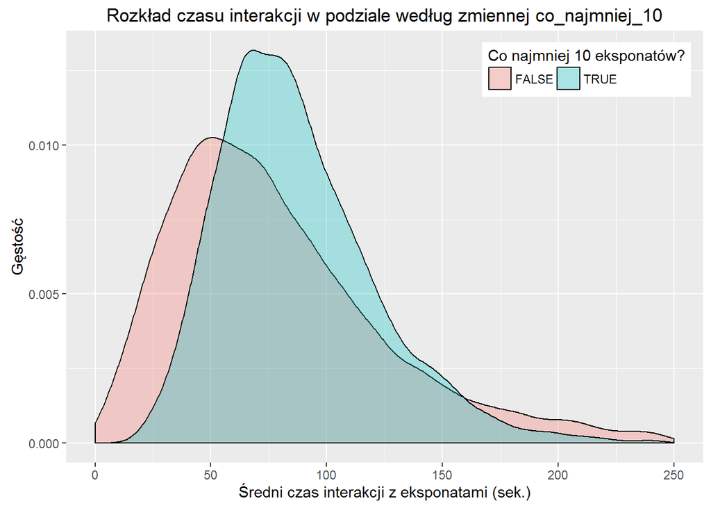

```r
ggplot(dane2, aes(x=czas_interakcji, fill=factor(co_najmniej_10))) + geom_density(alpha=.3) + xlim(0,250) + xlab("Średni czas interakcji z eksponatami (sek.)") + ylab("Gęstość") + theme_set(theme_gray(base_size = 12)) + theme(legend.justification=c(1,1), legend.position=c(1,1)) + guides(fill=guide_legend(title="Co najmniej 10 eksponatów?", ncol=2)) + ggtitle("Rozkład czasu interakcji w podziale według zmiennej co_najmniej_10")
```

### Klasteryzacja

W celu zidentyfikowania typowych ścieżek odwiedzających wystawę dokonamy klasteryzacji odwiedzających na kilka grup za pomocą metody k-medoidów, zilustrujemy medoidy (ścieżki reprezentujące klastry) na mapce centrum a następnie scharakteryzujemy każdy klaster za pomocą jednej składowej głównej, dzięki czemu stwierdzimy jakie zachowania odwiedzających najepiej objaśniają zmienność wewnątrz klastrów.

Wybrałyśmy metodę k-medoidów, ponieważ w przypadku naszych danych metoda ta ma znaczącą przewagę nad metodą k-średnich oraz grupowaniem hierarchicznym, gdyż jako jedyna pozwala na zidentyfikowanie medoidów, czyli w naszym przypadku reprezentantów wszystkich grup odwiedzających.

#### Wyznaczenie macierzy odległości

Przypomnijmy, że w naszej analizie wykorzystałyśmy dwie macierze (proces ich tworzenia został opisany w załączniku), które w różny sposób charakteryzują odwiedzających. Każda z nich ma w wierszech odwiedzających, a w kolumnach: (1) odwiedzone stacje lub (2) wykonane bilateralne przejścia. Są to macierze binarne, w których jedynki w komórkach wskazują na odwiedzenie danej stacji/wykonanie danego przejścia.

W tej części analizy wykonamy klasteryzację w oparciu o każdą z tych macierzy i wybierzemy podejście dające najlepsze rezultaty. Najpierw z każdej macierzy wybieramy podzbiór odwiedzających, którzy widzieli co najmniej 10 eksponatów:

```r
odwiedzajacy10 <- dane2[dane2$co_najmniej_10 == TRUE, "odwiedzajacy"]
wizyty_w10 <- wizyty_w[wizyty_w$odwiedzajacy %in% odwiedzajacy10, ] # macierz (1)
przejscia_w10 <- przejscia_w[przejscia_w$odwiedzajacy %in% odwiedzajacy10, ] # macierz (2)
```

Następnie dla każdej macierzy wyznaczymy macierz odległości z wykorzystaniem odległości Jaccarda, która np. dla macierzy (1) wynosi 0.5 pomiędzy dwoma odwiedzającymi jeśli obaj odwiedzili n tych samych stacji, a 2n to maksimum liczby odwiedzonych przez nich stacji (analogicznie dla przejść pomiędzy stacjami w macierzy (2)). Uważamy odległość Jaccarda za odpowiednią do naszej analizy, gdyż mierzy ona jaka część trasy dwóch zwiedzających była taka sama.

```r
# dist_wizyty <- vegdist(wizyty_w10[,-1], method="jaccard")
load("faza3_dist_wizyty.rda")
# dist_przejscia <- vegdist(przejscia_w10[,-1], method="jaccard")
load("faza3_dist_przejscia.rda")
```

#### Wybór liczby klastrów

Aby wybrać liczbę klastrów przyjrzałyśmy się dendrogramom metody hierarchicznej Warda. Wybrałyśmy tę metodę do stworzenia dendrogramów, ponieważ jedynie ona umożliwia taki wybór punktu odcięcia drzewa, który powoduje powstanie kilku klastrów o podobnym rozmiarze: w celu scharakteryzowania typowych ścieżek potrzebujemy właśnie takiego podziału. Powstałe dendrogramy znajdują się w załączniku: dla macierzy przejść na jego podstawie stwierdzamy, że w zależności od punktu odcięcia drzewa (który powinien być wybierany tak, żeby wybrana liczba klastrów była jak najbardziej odporna na zmianę wartości odcięcia) możemy wybrać dwa, trzy lub cztery klastry. Z kolei dla macierzy wizyt dendrogram sugeruje wybór dwóch, czterech lub sześciu klastrów.

Lepszym sposobem wyboru liczby klastrów jest obliczenie statystyki rozstępu (ang. gap-statistic). Robimy to w następnym kroku, jednak tylko dla macierzy wizyt - ze względu na wielkość macierzy przejść nie udało nam się wykonać tego dla niej. Choć można zmniejszyć rozmiar zadania przez wybór najpopularniejszych stacji uznałyśmy to za złe podejście w kontekście analizy całych ścieżek - w efekcie otrzymałybyśmy typowe “ścieżki z wyrwami”, a nie całe ścieżki!

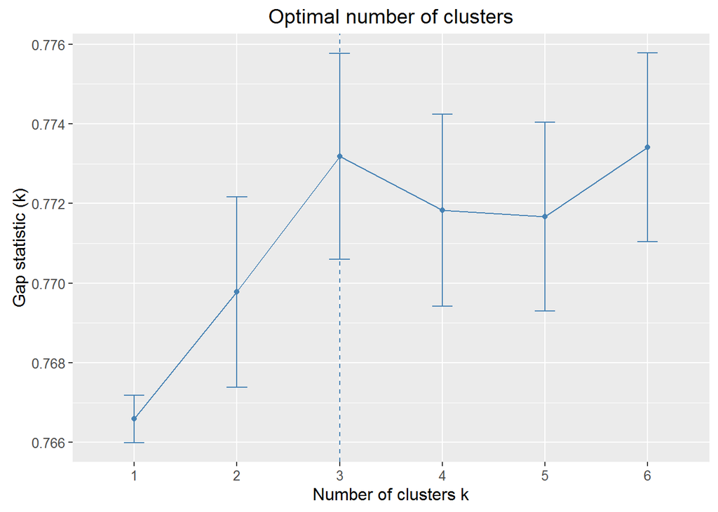

```r
#grupy_wizyty <- eclust(wizyty_w10[,-1], "pam", graph = FALSE, k.max = 6)
load("faza3_grupy_wizyty.rda")
fviz_gap_stat(grupy_wizyty$gap_stat)
```

Na podstawie powyższego wykresu stwierdzamy, że dobrą liczbą klastrów dla podziału na podstawie macierzy wizyt jest trzy (mogłoby być też sześć, ale wolimy mniej). Zauważmy, że w tym przypadku dendrogram wskazywał dwa, cztery lub sześć klastrów. Przewaga statystyki rozstępu jest taka, że wyznaczamy ją dla metody `pam()`, którą poźniej faktycznie dokonujemy klasteryzacji. Wybór liczby klastrów na podstawie dendrogramu nie jest poprawny jeśli potem dokonujemy klasteryzacji za pomocą innej metody (w tym przypadku k-medoidów). Niestety dla macierzy przejść nie mamy innego wyboru, więc zasugerujemy się wartościami wskazanymi na podstawie dendrogramu i wybierzemy lepszą na podstawie wykresu sylwetek.

#### Ocena wykonanej klasteryzacji

Ponieważ dwa klastry to za mało na potrzeby naszej analizy dokonałyśmy klastrowania na podstawie macierzy przejść na trzy i cztery klastry zaproponowane przez dendrogram oraz na podstwie macierzy wizyt na trzy klastry wskazane przez statystykę rozstępu.

```r
cluster_wizyty3 <- pam(dist_wizyty, k = 3)
cluster_przejscia3 <- pam(dist_przejscia, k = 3)
cluster_przejscia4 <- pam(dist_przejscia, k = 4)

# Tworzymy tabelkę z liczebnościami klastrów w zależności od podejścia
liczba_klastrow <- c(3,3,4)
macierz <- c("wizyty", "przejscia", "przejscia")
cbind(macierz, liczba_klastrow, rbind(table(factor(cluster_wizyty3$clustering, levels = 1:4)), table(factor(cluster_przejscia3$clustering, levels = 1:4)), table(factor(cluster_przejscia4$clustering, levels = 1:4))))
```

```
##      macierz     liczba_klastrow 1      2      3      4
## [1,] "wizyty"    "3"             "2638" "2124" "3924" "0"
## [2,] "przejscia" "3"             "2882" "2043" "3761" "0"
## [3,] "przejscia" "4"             "1760" "1867" "3159" "1900"
```

Powyższa tabelka pokazuje otrzymane liczebności klastrów w zależności od wyboru macierzy i liczby klastrów. Widać, że niezależnie od wykorzystanej macierzy i liczby klastrów jeden z nich jest zawsze znacznie większy od pozostałych.

Aby wybrać najlepsze klastrowanie stworzyłyśmy wykresy sylwetek dla każdego z rozważanych. Poniżej zamieszczamy wykres dla metody uznanej za najlepszą, a w załączniku pozostałe dwa.

```
##   cluster size ave.sil.width
## 1       1 2638          0.01
## 2       2 2124          0.03
## 3       3 3924          0.02
```

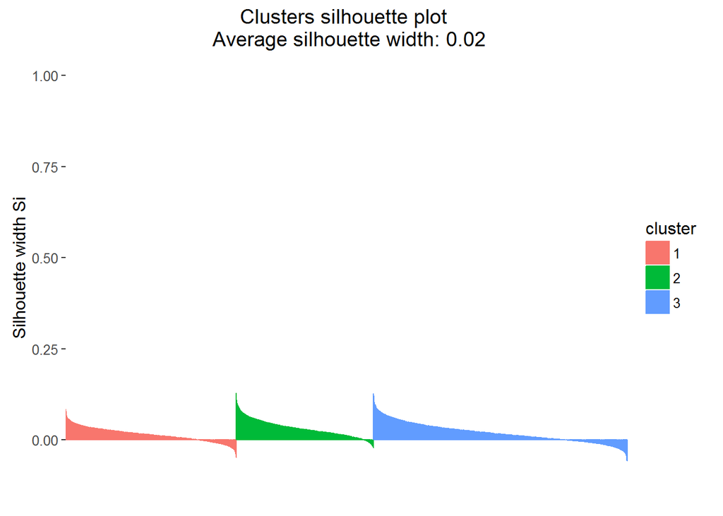

```r
syl_wizyty3 <- silhouette(cluster_wizyty3$clustering, dist_wizyty) # obliczamy sylwetki
fviz_silhouette(syl_wizyty3) # rysujemy wykres sylwetek
```

Na podstawie powyższego wykresu sylwetek możemy stwierdzić, że ogólnie ta klasteryzacja nie jest najlepsza (ale przyglądając się pozostałym wykresom z załącznika stwierdzamy, że jest najlepsza spośród trzech przez nas rozważanych).

Niezależnie od wyboru macierzy i liczby klastrów otrzymany wykres sylwetek charakteryzuje się dużą liczbą wartości ujemnych (odwiedzający, którym bliżej do sąsiedniego klastra niż do swojego) i bardzo małymi wartościami dodatnimi sylwetek (małym podobieństwem w obrębie klastrów). Może to świadczyć o złym doborze odległości, jednak dla takich macierzy nasz wybór jest dobrze uzasadniony i ciężko wyobrazić sobie lepszy. W przypadku macierzy przejść wykres sylwetek wydaje się być lepszy dla podziału na cztery klastry.

W naszej opinii takie wykresy sylwetek wynikają po prostu z bardzo dużego zróżnicowania ścieżek odwiedzających. Potwierdza to duża różnica pomiędzy sylwetkami dla klasteryzacji na podstawie przejść i klasteryzacji na podstawie wizyt - ta ostatnia ma wyraźnie lepsze sylwetki (jeśli wyeliminujemy informację o kolejności zwiedzanych stacji, to możemy znaleźć bardziej jednolite klastry odwiedzających).

#### Charakteryzacja klastrów

Medoidy najlepszego w naszej opinii podziału (na trzy klastry podstawie macierzy wizyt) oznaczyłyśmy na poniższej mapce. Analogiczna mapka dla podziału na cztery klastry na podstawie macierzy przejść znajduje się w załączniku.

```r
cluster_wizyty3$medoids # Odwiedzający-medoidy
```

```
## [1] "803649" "822958" "817877"
```

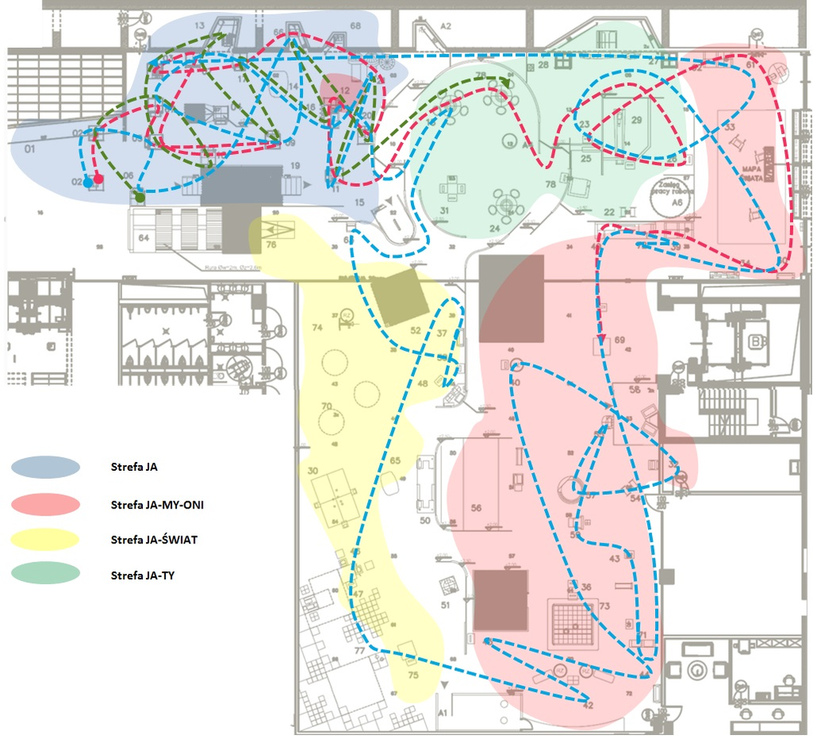

Na mapce widać, że tylko jeden z trzech reprezentantów odwiedza wszystkie cztery strefy. Pozostali dwaj skupiają się na strefach, które są najbliżej wejścia, czyli strefie JA oraz strefie JA-TY. Oznacza to, że większa część odwiedzających rozpoczynając od początku wystawy, wchodzi w interakcję z dużą ilością początkowych eksponatów, ale po pewnym czasie rezygnuje z dalszego zwiedzania, nie korzystając z pozostałych stref.

Aby potwierdzić nasze przypuszczenia o tym, że pierwsze dwie strefy są faworyzowane przez architekturę, wyodrębnimy najpopularniejsze stacje w obrębie każdego z klastrów. Za pomocą poniższego kodu wyznaczamy 10 najpopularniejszych stacji dla każdego klastra i następnie zaznaczamy je na mapce, gdzie kolory są analogiczne do poprzednio używanych (1. klaster - czerwony, 2. klaster - zielony, 3. klaster - niebieski).

```r
dane4 <- wizyty_w10
dane4$klastry <- cluster_wizyty3$clustering
pop1 <- as.data.frame(colSums(dane4[dane4$klastry == 1, -c(1,61)])/nrow(dane4[dane4$klastry == 1,]))
names(pop1) <- "czestosc"
pop1$stacja <- rownames(pop1)
pop2 <- as.data.frame(colSums(dane4[dane4$klastry == 2, -c(1,61)])/nrow(dane4[dane4$klastry == 2,]))
names(pop2) <- "czestosc"
pop2$stacja <- rownames(pop2)
pop3 <- as.data.frame(colSums(dane4[dane4$klastry == 3, -c(1,61)])/nrow(dane4[dane4$klastry == 3,]))
names(pop3) <- "czestosc"
pop3$stacja <- rownames(pop3)
# Tabelka częstości odwiedzin stacji w obrębie klastrów
cbind(head(pop1[order(pop1$czestosc, decreasing = TRUE),], 10), head(pop2[order(pop2$czestosc, decreasing = TRUE),], 10), head(pop3[order(pop3$czestosc, decreasing = TRUE),], 10))
```

```
##         czestosc stacja  czestosc stacja  czestosc stacja
## cnk16  0.5500379  cnk16 0.6341808  cnk16 0.4533639  cnk79
## cnk78a 0.5140258 cnk78a 0.5706215  cnk12 0.4273700  cnk16
## cnk12  0.5125095  cnk12 0.5296610  cnk17 0.4153925  cnk69
## cnk61  0.4700531  cnk61 0.5018832  cnk09 0.4082569  cnk32
## cnk18  0.4655042  cnk18 0.4985876  cnk10 0.4046891  cnk40
## cnk69  0.4492039  cnk69 0.4835217  cnk66 0.3914373  cnk18
## cnk09  0.4313874  cnk09 0.4774011  cnk07 0.3906728  cnk37
## cnk72  0.4272176  cnk72 0.4736347  cnk18 0.3904179  cnk12
## cnk39  0.4203942  cnk39 0.4665725  cnk05 0.3786952  cnk55
## cnk23  0.4135709  cnk23 0.4548023  cnk20 0.3766565 cnk42a
```

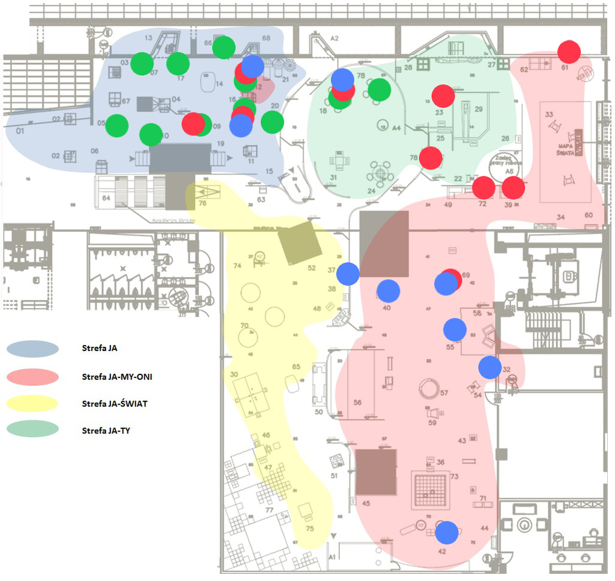

Powyższa mapa potwierdza spostrzeżenia dokonane na podstawie medoidów: najpopularniejsze stacje dla klastra zielonego znajdują się głównie w strefie JA, czerwonego również w strefie JA-TY oraz JA-MY-ONI, jednak w większości w górnej części mapki, natomiast najpopularniejsze stacje dla klastra niebieskiego znajdują się we wszystkich strefach, przy czym aż połowa w strefie JA-MY-ONI. Należy również zauważyć, że stacje **cnk12**, **cnk16** oraz **cnk18** znajdują się wśród 10 najpopularniejszych stacji w obrębie każdego z klastrów.

Nasza sugestia jest taka, żeby poszerzyć wejście i architektonicznie zachęcić osoby do kierowania się do stref mniej uczęszczanych.

### Analiza składowych głównych dla klastrów

W celu pełnego zrozumienia wyników naszej klasteryzacji wykonujemy analizę składowych głównych w obrębie każdego z trzech klastrów i porównujemy pierwszą składową główną (wyjaśniającą najwięcej wariancji) pomiędzy klastrami. Pozwoli to na zidentyfikowanie eksponatów, których odwiedzenie lub nieodwiedzenie w największym stopniu charakteryzuje (wyjaśnia zmienność) każdy z klastrów, a więc wyjaśnienie zróżnicowania w obrębie klastrów.

```r
# PCA w klastrach: tylko centrujemy nasze zmienne gdyż są w tej samej jednostce
pca1 <- prcomp(dane4[dane4$klastry == 1, -c(1,61)], center = TRUE)
pca2 <- prcomp(dane4[dane4$klastry == 2, -c(1,61)], center = TRUE)
pca3 <- prcomp(dane4[dane4$klastry == 3, -c(1,61)], center = TRUE)
klaster1_pc1 <- as.data.frame(pca1$rotation[, 1])
klaster1_pc1$stacja <- rownames(klaster1_pc1)
klaster2_pc1 <- as.data.frame(pca2$rotation[, 1])
klaster2_pc1$stacja <- rownames(klaster2_pc1)
klaster3_pc1 <- as.data.frame(pca3$rotation[, 1])
klaster3_pc1$stacja <- rownames(klaster3_pc1)
# Pięć najbardziej wpływowych składników pierwszej składowej (analogicznie dla pozostałych)
a <- as.matrix(head(klaster1_pc1[order(abs(klaster1_pc1[,1]), decreasing = TRUE), ],5))
b <- as.matrix(head(klaster2_pc1[order(abs(klaster2_pc1[,1]), decreasing = TRUE), ],5))
c <- as.matrix(head(klaster3_pc1[order(abs(klaster3_pc1[,1]), decreasing = TRUE), ],5))
x <- cbind(a,b,c)
rownames(x) <- NULL
x
```

```
##      pca1$rotation[, 1] stacja  pca2$rotation[, 1] stacja
## [1,] "-0.2812750"       "cnk10" "0.3099306"        "cnk66"
## [2,] "-0.2783107"       "cnk09" "0.3025150"        "cnk07"
## [3,] "-0.2609400"       "cnk12" "0.2959078"        "cnk09"
## [4,] "-0.2596425"       "cnk17" "0.2941068"        "cnk05"
## [5,] "-0.2576873"       "cnk05" "0.2914005"        "cnk10"
##      pca3$rotation[, 1] stacja
## [1,] "-0.2383946"       "cnk12"
## [2,] "-0.2286952"       "cnk09"
## [3,] "-0.2179231"       "cnk66"
## [4,] "-0.2148051"       "cnk16"
## [5,] "-0.2112756"       "cnk07"
```

W powyższej tabelce znajduje się 5 wspórzędnych pierwszej składowej głównej o najwyższej wartości bezwzględnej dla każdego z klastrów. Są to eksponaty, których obejrzenie (bądź nieobejrzenie, jeśli znak jest ujemny) ma największy wkład w pierwszy wymiar w obrębie każdego z klastrów, a więc charakteryzują odwiedzających w danym klastrze. Niestety w każdym przypadku udział w wyjaśnionej wariancji pierwszej składowej wyniósł od 5 do 8%, czyli niewiele.

Aby wyjaśnić 20% wariancji w obrębie każdego klastra trzeba wziąć pierwsze 6 składowych. Aby zobrazować te składowe na mapce dla każdej z nich bierzemy pięć stacji, dla których współczynnik ma najwyższą wartość bezwzględną i zaznaczamy je na poniższej mapce (czerwony odpowiada pierwszemu klastrowi, zielony drugiemu, a niebieski trzeciemu). Intensywność koloru odpowiada numerowi składowej (najintensywniejszy jest dla pierwszej), ponadto nie zaznaczamy powtórnie tych samych stacji (niektóre mają duży współczynnik w kilku składowych).

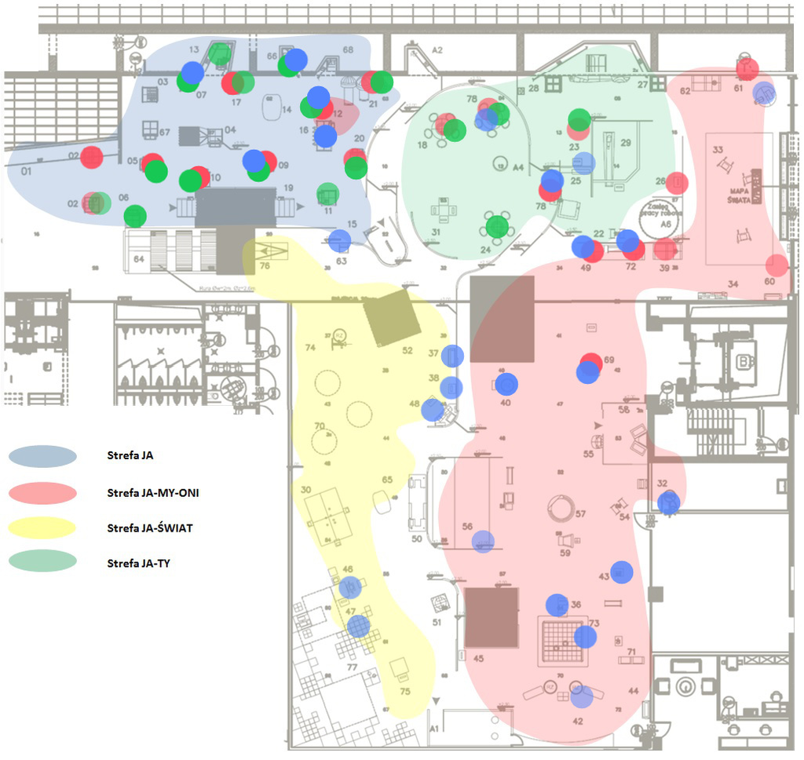

Na podstawie mapki widzimy, że stacje wyjaśniające zróżnicowanie w obrębie klastrów rozkładają się w strefach wystawy podobnie, jak stacje, które je charakteryzują (np. stacje wchodzące w skład medoidów). Należ jednak zauważyć, że stacje grające dużą rolę w pierwszej składowej w większości znajdują się w strefie JA, niezależnie od rozpatrywanego klastra.

## Podsumowanie

#### 1. Z czego wynika popularność poszczególnych eksponatów? Czy popularne eskponaty zawsze są ciekawe?

Popularność danego eksponatu w głównej mierze zależy od jego usytuowania na mapie wystawy. Większość popularnych stacji swoją popularność zawdzięcza umiejscowieniu blisko wejścia, a pozostała część uwarunkowaniom architektonicznym, które wprost prowadzą odwiedzającego do konkretnego eksponatu. Wygląda na to, że organizatorzy mogą tak dobrać ułożenie eksponatów, aby przyciągnąć większą liczbę odwiedzających do wybranych eksponatów.

Na wykresach widzieliśmy również, że stacje popularne często okazywały się stacjami na tyle nieciekawymi, że zwiedzający rezygnowali z interakcji z nimi w pierwszych 10 sekundach, ale z drugiej strony do niektórych z nich wracali na kolejną interakcję, co sugeruje problemy z kolejkami do tych stacji.

#### 3. Jakie ścieżki są typowe i co wpływa na ich powstawanie?

Zastosowanie reguł asocjacyjnych nie wykazało silnych zależności pomiędzy stacjami oraz ścieżkami między nimi. Oznacza to, że sposób poruszania się odwiedzających nie jest zupełnie deterministyczny. Można jednak wyodrębnić część podścieżek, które charakteryzują się większą popularnością niż pozostałe połączenia - znajdują się one głównie w owalnej, ograniczonej półściankami, części wystawy JA-TY. Do powstania tych podścieżek przyczyniły się w głównej mierze uwarunkowania architektoniczne wystawy.

#### 4. Jak architektura wystawy wpływa na sposób poruszania się odwiedzających po niej?

Z naszej analizy wynika, że rozmieszczenie eksponatów gra kluczową rolę: najczęściej odwiedzane są eksponaty przy wejściu, które jest wąskie, tam też odwiedzający najczęściej wracają na powtórne interakcje. Mało kto dochodzi do strefy JA-ŚWIAT, zapewne dlatego, że owalna część wystawy JA-TY sugeruje poruszanie się wokół wystawy według ruchu wskazówek zegara - w tym układzie sekcja JA-ŚWIAT znajduje się na samym końcu. Głównym mankamentem wystawy wydaje się być wąskie gardło przy wejściu do niej.

#### 5. Która strefa cieszy się największą popularnością wśród odwiedzających i dlaczego?

Najwięszką popularnością cięszą się dwie pierwsze strefy - strefa JA oraz strefa JA-TY. Jest to spowodowane tym, że strefy te znajdują się najbliżej wejścia i zdecydowana większość osób zaczyna zwiedzanie wystawy właśnie od nich. Jak wykazały nasze statystyki, duża część osób rezygnuje z dalszego zwiedzania właśnie po obejrzeniu tych stref, nie rozpoczynając nawet interakcji z pozostałymi. Nasza sugestia jest taka, żeby na początku wystawy umieścić pomocniczy schemat rozmieszczenia poszczególnych stref tak, aby zwiedzający mogli sami zdecydować na co poświęcić swój czas i od razu udać się do strefy, która najbardziej ich interesuje. Takie rozwiązanie mogłoby zmniejszyć liczbę przypadkowych wejść do pierwszych stacji oraz zwiększyć satysfakcję odwiedzających z pobytu na wystawie Regeneracja.

## Załączniki

### Przetwarzanie danych

#### Tworzenie podstawowego zbioru danych

Najpierw wybieramy odpowiedni podzbiór danych, numerujemy kolejne interakcje poszczególnych odwiedzających z eksponatami, obliczamy czasy interakcji, a następnie tworzymy zmienną “przejścia”, która zawiera informację o bilateralnym przejściu pomiędzy eksponatami.

```r
setwd("~/UW/Statystyka_II/Projekt1")
load("C:/Users/Ja/Documents/UW/Statystyka_II/Projekt1/smallLogs.rda")

# Obróbka danych, wybór obserwacji ze stycznia
data <- smallLogs
data$month <- format(data$date, "%m") # tworzymy zmienną określającą miesiąc wizyty
table(data$month)
data <- subset(data, month == "01")[,1:4] # wybieramy dane ze stycznia, usuwamy informację o maszynach (chcemy analizować całe eksponaty)
data <- subset(data, visitor != "-1") # usuwamy odwiedzającego, który prawdopodobnie jest pracownikiem CNK (nietypowy numer, często się pojawia)
table(smallLogs$station[smallLogs$visitor=="-1"]) # zauważmy, że pracownik techniczny "pracował" tylko nad niektórymi eksponatami
data$station <- droplevels(data$station) # usuwamy poziomy zmiennej station, dla których jest zero obserwacji
data$visitor <- as.factor(data$visitor)

# Dzielimy zbiór na wejścia i wyjścia i sortujemy po numerach odwiedzających
data_ent <- subset(data, type == "Entering")[,1:3]
data_ent <- data_ent[order(data_ent$visitor, data_ent$date),]
data_leav <- subset(data, type == "Leaving")[,1:3]
data_leav <- data_leav[order(data_leav$visitor, data_leav$date),]

# Oznaczamy pierwsze (z rzędu) wejście i ostatnie wyjście z każdej ze stacji żeby usunąć wielokrotne logowania co kilka sekund
data_ent$delete <- 0
for(i in 2:nrow(data_ent)){
    if((data_ent$visitor[i] == data_ent$visitor[i-1]) && (data_ent$station[i] == data_ent$station[i-1])){
        data_ent$delete[i] <- 1
        print(i)
    }
}
data_ent_deleted <- subset(data_ent, delete == 0)[,1:3] # zostawiamy tylko pierwsze z rzędu logowania do eksponatu
data_leav$delete <- 0
for(i in (nrow(data_leav)-1):1){
    if((data_leav$visitor[i] == data_leav$visitor[i+1]) && (data_leav$station[i] == data_leav$station[i+1])){
        data_leav$delete[i] <- 1
        print(i)
    }
}
data_leav_deleted <- subset(data_leav, delete == 0)[,1:3] # zostawiamy tylko ostatnie z rzędu wylogowywania z eksponatu

# Numerujemy logowania i wylogowywania każdego odwiedzającego do każdego eksponatu
data_ent_deleted <- data_ent_deleted[order(data_ent_deleted$visitor, data_ent_deleted$station, data_ent_deleted$date),]
data_ent_deleted$nr <- 1
for(i in 2:nrow(data_ent_deleted)){
    if((data_ent_deleted$visitor[i] == data_ent_deleted$visitor[i-1]) &&
       (data_ent_deleted$station[i] == data_ent_deleted$station[i-1])){
        data_ent_deleted$nr[i] <- data_ent_deleted$nr[i-1]+1
        print(i)
    }
}
data_leav_deleted <- data_leav_deleted[order(data_leav_deleted$visitor, data_leav_deleted$station, data_leav_deleted$date),]
data_leav_deleted$nr <- 1
for(i in 2:nrow(data_leav_deleted)){
    if((data_leav_deleted$visitor[i] == data_leav_deleted$visitor[i-1]) &&
       (data_leav_deleted$station[i] == data_leav_deleted$station[i-1])){
        data_leav_deleted$nr[i] <- data_leav_deleted$nr[i-1]+1
        print(i)
    }
}

# Wyznaczamy czasy interakcji z eksponatami
# Łączymy logowania z wylogowaniami dla każdej z odwiedzonych przez danego odwiedzającego stacji, według numeru "wizyty"
data_both <- merge(data_ent_deleted, data_leav_deleted, by=c("visitor", "station", "nr"))
data_both$czas <- as.numeric(data_both$date.y-data_both$date.x) # date.x to czas logowania, date.y to czas wylogowywania
data_both[data_both$czas < 0,] # sprawdzamy, czy czasy nie ma ujemnych wartości - są dwie, więc to mogą być zwykłe błędy
data_both <- subset(data_both, czas >= 0) # usuwamy te dwie podejrzane obserwacje

# Tworzymy zmienną "skad" oznaczającą poprzednią odwiedzoną stację w każdym wierszu oraz zmienną
# "przejscie" zawierającą bilateralne przejście pomiędzy skąd a obecną stacją dla danego wiersza
data_both <- data_both[order(data_both$visitor, data_both$date.x),] # sortujemy dane
data_both$przejscie <- NA
data_both$skad <- NA
for(i in 2:nrow(data_both)){
    if(data_both$visitor[i] == data_both$visitor[i-1]){
        data_both$przejscie[i] <- paste0(data_both$station[i-1], paste0("->", data_both$station[i]))
        data_both$skad[i] <- paste0(data_both$station[i-1])
        print(i)
    }
}
colnames(data_both) <- c("odwiedzajacy", "stacja", "nr_interakcji", "data_wejscia", "data_wyjscia", "czas_interakcji", "przejscie", "poprzednia_stacja")
save(data_both, file="faza3_dane.rda") # zapisujemy zbiór - to jest nasza podstawowa ramka danych
```

#### Tworzenie trzech podstawowych macierzy

Drugi krok przetwarzania danych to utworzenie macierzy, które mają w wierszach odwiedzających, a w kolumnach odpowiednie charakterystyki wizyty odwiedzających wystawę Regeneracja. Do naszych analiz potrzebne są nam trzy macierze mające w wierszach odwiedzających.

- Macierz binarna ze stacjami w kolumnach i wartością 1 w komórce jeśli dany odwiedzający wszedł w interakcję z danym eksponatem.

```r
wizyty <- subset(data_both, nr_interakcji == 1)[,1:3] # wybieramy jedynie pierwszą interakcję odwiedzającego z eksponatem
wizyty_w <- spread(wizyty, key = stacja, value = nr_interakcji, fill = 0) # macierz w postaci szerokiej
save(wizyty_w, file="faza3_wizyty.rda") # zapisujemy macierz
```

- Macierz ze stacjami w kolumnach i średnim czasem interakcji danego odwiedzającego z daną stacją w komórkach.

```r
# Jeśli jest kilka interakcji z tym samym eksponatem to uśredniamy - dzieje się to relatywnie rzadko, a czasy kolejnych interakcji są przeciętnie dłuższe:
aggregate(czas_interakcji ~ nr_interakcji, data = data_both, mean)
czasy <- aggregate(czas_interakcji ~ odwiedzajacy + stacja, data = data_both, mean)
czasy_w <- spread(czasy, key = stacja, value = czas_interakcji, fill = 0) # macierz w postaci szerokiej
save(czasy_w, file="faza3_czasy.rda") # zapisujemy macierz
```

- Macierz z bilateralnymi przejściami pomiędzy stacjami w kolumnach i wartością 1 w komórce jeśli dany odwiedzający dokonał takiego przejścia.

```r
przejscia <- subset(data_both, !is.na(przejscie))[,c(1,7)] # wyrzucamy braki danych, które powstały w wyniku zamiany ścieżek
# długości n dla każdego odwiedzającego na sekwencję n-1 bilateralnych przejść
przejscia$kolumna_jedynek <- 1 # musimy mieć wartości, które pojawią się w macierzy w postaci szerokiej
przejscia1 <- aggregate(kolumna_jedynek ~ odwiedzajacy + przejscie, data = przejscia, mean) # eliminujemy powtarzające się przejścia
przejscia_w <- spread(przejscia1, key = przejscie, value = kolumna_jedynek, fill = 0) # macierz w postaci szerokiej
save(przejscia_w, file="faza3_przejscia.rda") # zapisujemy macierz
```

#### Najpopularniejsze eksponaty i przejścia pomiędzy eksponatami

Teraz wykonamy obliczenia potrzebne do konstrukcji mapek wystawy. Oto 5 najczęściej odwiedzanych stacji.

```r
x <- as.data.frame(table(data_both$stacja)) # tabela częstości ostatnich stacji
head(x[order(x$Freq, decreasing = TRUE), ], n=5)
```

```
##      Var1 Freq
## 13  cnk16 7225
## 1  cnk02a 6442
## 11  cnk12 6041
## 15  cnk18 5977
## 2  cnk02b 5624
```

Oto 5 najczęściej przebytych przejść pomiędzy stacjami.

```r
x <- as.data.frame(table(data_both$przejscie)) # tabela częstości ostatnich stacji
head(x[order(x$Freq, decreasing = TRUE), ], n=5)
```

```
##                Var1 Freq
## 895  cnk19a->cnk19b 1736
## 877   cnk18->cnk78a 1525
## 601    cnk12->cnk20 1100
## 3293  cnk78a->cnk23  983
## 602    cnk12->cnk21  980
```

#### Pierwsze i ostatnie stacje

W analizie wykorzystałyśmy również informacje dotyczące pierwszych i ostatnich odwiedzonych stacji. W celu otrzymania tych danych wykonałyśmy następujące przekształcenia.

```r
stacje <- as.data.frame(data_both$odwiedzajacy)
stacje$pierwsza <- NA
stacje$pierwsza[1] <- as.character(data_both$stacja[1])
stacje$ostatnia <- NA
stacje$ostatnia[1] <- as.character(data_both$stacja[1])
stacje$ostatnia[nrow(data_both)] <- as.character(data_both$stacja[nrow(data_both)])
for(i in 2:(nrow(data_both)-1)){
    if(data_both$odwiedzajacy[i] != data_both$odwiedzajacy[i-1]){
        stacje$pierwsza[i] <- as.character(data_both$stacja[i])
    }
    if(data_both$odwiedzajacy[i] != data_both$odwiedzajacy[i+1]){
        stacje$ostatnia[i] <- as.character(data_both$stacja[i])
    }
}
```

Oto 5 stacji, które były najczęściej odwiedzane jako pierwsze.

```r
x <- as.data.frame(table(stacje$pierwsza)) # tabela częstości pierwszych stacji
head(x[order(x$Freq, decreasing = TRUE), ], n=5)
```

```
##      Var1 Freq
## 1  cnk02a 3944
## 2  cnk02b 3570
## 52  cnk67 1089
## 4   cnk05 1015
## 8   cnk10 1010
```

Oto 5 stacji, które były najczęściej odwiedzane jako ostatnie.

```r
x <- as.data.frame(table(stacje$ostatnia)) # tabela częstości ostatnich stacji
head(x[order(x$Freq, decreasing = TRUE), ], n=5)
```

```
##      Var1 Freq
## 50 cnk63a 1125
## 25 cnk29a  815
## 32 cnk42a  787
## 43  cnk56  780
## 9  cnk100  734
```

#### Pierwsze i ostatnie przejścia pomiędzy eksponatami

Analogicznie, przekształciłyśmy dane w celu zidentyfikowania pierwszych i ostatnich bilateralnych przejść pomiędzy eksponatami dla każdego odwiedzającego.

```r
data_both1 <- data_both[!is.na(data_both$przejscie),]
przejscia1 <- as.data.frame(data_both1$odwiedzajacy)
przejscia1$pierwsza <- NA
przejscia1$pierwsza[1] <- data_both1$przejscie[1]
przejscia1$ostatnia <- NA
przejscia1$ostatnia[nrow(data_both1)] <- data_both1$przejscie[nrow(data_both1)]
for(i in 2:(nrow(data_both1)-1)){
    if(data_both1$odwiedzajacy[i] != data_both1$odwiedzajacy[i-1]){
        przejscia1$pierwsza[i] <- data_both1$przejscie[i]
    }
    if(data_both1$odwiedzajacy[i] != data_both1$odwiedzajacy[i+1]){
        przejscia1$ostatnia[i] <- data_both1$przejscie[i]
    }
}
```

Oto 5 przejść, które były najczęściej wykonywane jako pierwsze.

```r
x <- as.data.frame(table(przejscia1$pierwsza)) # tabela częstości pierwszych przejsc
head(x[order(x$Freq, decreasing = TRUE), ], n=5)
```

```
##              Var1 Freq
## 59 cnk02b->cnk02a  543
## 51  cnk02a->cnk67  542
## 66 cnk02b->cnk100  497
## 3   cnk02a->cnk05  466
## 7   cnk02a->cnk10  414
```

Oto 5 przejść, które były najczęściej wykonywane jako ostatnie.

```r
x <- as.data.frame(table(przejscia1$ostatnia)) # tabela częstości ostatnich przejść
head(x[order(x$Freq, decreasing = TRUE), ], n=5)
```

```
##                Var1 Freq
## 751  cnk19a->cnk19b  274
## 1391  cnk37->cnk63a  122
## 958   cnk22->cnk29a  111
## 1950 cnk48a->cnk63a   96
## 1119  cnk25->cnk29a   93
```

### Uzupełnienia: wstępna eksploracja danych

#### Liczba interakcji z danym eksponatem

Porównajmy listę najpopularniejszych eksponatów ogólnie z listą najpopularniejszych eksponatów pod względem powtórnych odwiedzin:

```r
# wybieramy nazwy stacji najpopularniejszych ogółem i najczęściej odwiedzanych powtórnie
temp4 <- rbind(as.character(head(temp[order(temp$Freq, decreasing = TRUE), "Var1"], n=10)), as.character(head(temp1[order(temp1$Freq, decreasing = TRUE), "Var1"], n=10)))
rownames(temp4) <- c("Najpopularniejsze", "Najczęściej odwiedzane powtórnie")
colnames(temp4) <- as.character(1:10)
t(temp4)
```

```
##    Najpopularniejsze Najczęściej odwiedzane powtórnie
## 1  "cnk16"           "cnk100"
## 2  "cnk02a"          "cnk02b"
## 3  "cnk12"           "cnk02a"
## 4  "cnk18"           "cnk78a"
## 5  "cnk02b"          "cnk56"
## 6  "cnk10"           "cnk16"
## 7  "cnk09"           "cnk10"
## 8  "cnk78a"          "cnk19a"
## 9  "cnk17"           "cnk07"
## 10 "cnk05"           "cnk17"
```

Na podstawie powyższej tabeli można stwierdzić, że rankingi te nieznacznie różnią się kolejnością, natomiast zawierają podobne stacje (tylko cztery stacje spośród najpopularniejszych ogółem okazują się nie być wśród 10 najczęściej odwiedzanych powtórnie). Obliczmy współczynnik korelacji Spearmana.

```r
temp[order(temp$Freq), "rank"] <- 1:nrow(temp)
temp1[order(temp1$Freq), "rank"] <- 1:nrow(temp1)
temp5 <- merge(temp1, temp, by = "Var1")
cor(temp5$rank.x, temp5$rank.y, method = "spearman")
```

```
## [1] 0.5676797
```

Współczynnik korelacji Spearmana dla tych dwóch rankingów wyniósł prawie 57%, co stanowi dość silną korelację. Na tej podstawie stwierdzamy, że powtórne odwiedzanie danej stacji jest związane głównie z jej ogólną popularnością.

#### Średni czas interakcji dla poszczególnych eksponatów

Zastanówmy się, czy średni czas interakcji z eksponatem jest charakterystyczny dla eksponatu (z powyższych rozważań widać, że kształt rozkładów różni się znacznie pomiędzy stacjami). Następujący wykres przedstawia średni czas interakcji w kolejności od najwyższego do najniższego.

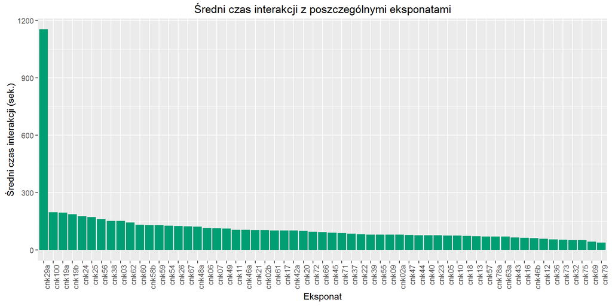

```r
temp0 <- aggregate(czas_interakcji ~ stacja, data_both, mean)
temp0 <- temp0[order(temp0$czas_interakcji, decreasing = TRUE),]
temp0 <- within(temp0, stacja <- factor(stacja, levels=as.character(temp0[order(temp0$czas_interakcji, decreasing = TRUE), "stacja"])))
ggplot(temp0, aes(stacja, czas_interakcji)) + geom_bar(stat = "identity", fill = "#009E73") + xlab("Eksponat") + ylab("Średni czas interakcji (sek.)") + theme(axis.text.x=element_text(angle = 90, hjust = 1)) + guides(fill=FALSE) + ggtitle("Średni czas interakcji z poszczególnymi eksponatami")
```

Na podstawie wykresu możemy stwierdzić, że średni czas interakcji z eksponatem nie różni się zbytnio pomiędzy eksponatami (z wyjątkiem stacji **cnk29a**).

#### Model regresji liniowej dla średniego czasu interakcji

Możemy podejrzewać, że dla poszczególnych odwiedzających średni czas interakcji z eksponatami zależy tego, jakie stacje odwiedzili - np. ciekawsze stacje zachęciły ich do intensywnego eksplorowania wystawy. Zbadamy to za pomocą modelu regresji liniowej objaśniającego średni czas interakcji dla odwiedzającego zmiennymi binarnymi wskazującymi na odwiedzone stacje (eliminujemy ze zbioru zmienną odpowiadającą stacji **cnk29a**, ze względu na nietypowy średni czas interakcji dla niej).

```r
dane1 <- merge(wizyty_w, sredni_czas, by = "odwiedzajacy") # włączamy do zbioru danych
model1 <- lm(czas_interakcji ~ ., data = dane1[,-c(1,26)]) # konstuujemy model regresji liniowej
model1_maly <- stepAIC(model1, trace=FALSE) # selekcja wsteczna maksymalizująca kryterium AIC
summary(model1_maly) # oszacowania parametrów modelu - w załączniku
```

```
##
## Call:
## lm(formula = czas_interakcji ~ cnk02a + cnk62 + cnk78a + cnk79,
##     data = dane1[, -c(1, 26)])
##
## Residuals:
##    Min     1Q Median     3Q    Max
##   -162    -73    -41     -4 133941
##
## Coefficients:
##             Estimate Std. Error t value Pr(>|t|)
## (Intercept)  134.197      9.932  13.511   <2e-16 ***
## cnk02a       -29.483     17.576  -1.677   0.0935 .
## cnk62         31.249     21.572   1.449   0.1475
## cnk78a       -27.380     19.010  -1.440   0.1498
## cnk79        -33.506     20.497  -1.635   0.1021
## ---
## Signif. codes:  0 '***' 0.001 '**' 0.01 '*' 0.05 '.' 0.1 ' ' 1
##
## Residual standard error: 1165 on 23958 degrees of freedom
## Multiple R-squared:  0.0004318,  Adjusted R-squared:  0.000265
## F-statistic: 2.588 on 4 and 23958 DF,  p-value: 0.03495
```

```r
# Szacujemy parametry regresji liniowej
model2 <- lm(czas_interakcji ~ ., data = dane2[,-c(1,26,64,65)])
model2_maly <- stepAIC(model2, trace=FALSE) # selekcja wsteczna maksymalizująca kryterium AIC
summary(model2_maly)
```

```
##
## Call:
## lm(formula = czas_interakcji ~ cnk02a + cnk26 + cnk62 + cnk78a +
##     cnk79 + godzina, data = dane2[, -c(1, 26, 64, 65)])
##
## Residuals:
##    Min     1Q Median     3Q    Max
##   -543    -58    -27      7  67182
##
## Coefficients:
##             Estimate Std. Error t value Pr(>|t|)
## (Intercept)  119.880     41.274   2.904  0.00368 **
## cnk02a       -20.560     11.259  -1.826  0.06784 .
## cnk26         30.483     15.770   1.933  0.05325 .
## cnk62         35.083     13.950   2.515  0.01191 *
## cnk78a       -22.014     12.273  -1.794  0.07288 .
## cnk79        -24.530     13.212  -1.857  0.06338 .
## godzina10     -7.145     45.044  -0.159  0.87398
## godzina11    -21.633     43.121  -0.502  0.61589
## godzina12     -7.757     42.671  -0.182  0.85575
## godzina13    -18.525     42.977  -0.431  0.66644
## godzina14    -18.763     42.781  -0.439  0.66097
## godzina15      4.685     42.909   0.109  0.91306
## godzina16     -2.365     43.326  -0.055  0.95647
## godzina17     15.941     45.260   0.352  0.72468
## godzina18    414.646     57.132   7.258 4.06e-13 ***
## ---
## Signif. codes:  0 '***' 0.001 '**' 0.01 '*' 0.05 '.' 0.1 ' ' 1
##
## Residual standard error: 745 on 23895 degrees of freedom
## Multiple R-squared:  0.005706,   Adjusted R-squared:  0.005123
## F-statistic: 9.794 on 14 and 23895 DF,  p-value: < 2.2e-16
```

- osoby, które odwiedziły stację **cnk02a**, **cnk78a** lub **cnk79** mają średnio niższy średni czas interakcji niż osoby, które tej stacji nie odwiedziły,
- osoby, które odwiedziły stację **cnk26** lub **cnk62** mają średnio wyższy średni czas interakcji niż osoby, które tej stacji nie odwiedziły,
- osoby, które weszły w interakcję z pierwszym eksponatem na wystawie Regeneracja po 18:00 mają wyższy średni czas interakcji przeciętnie o ponad 400 sekund w porównaniu do osób, które w pierwszą interakcję na wystawie weszły o godzinie 9:00 (to jest kategoria referencyjna dla zmiennej jakościowej godzina).

Szczególnie ciekawe wydają się stacje, których odwiedzenie wiąże się z wyższym lub niższym średnim czasem interakcji - z wykresu średnich czasów interakcji dla eksponatów widać, że raczej ta zależność nie wynika z tego, że wymienione eksponaty po prostu wymagały więcej czasu, ponieważ średnie czasy dla eksponatów niewiele się między sobą różniły oraz dla wielu eksponatów o dość wysokim średnim czasie interakcji parametr w modelu okazał się nieistotny.

#### Liczby odwiedzonych eksponatów

Do badania ścieżek odwiedzających warto jest zorientować się jaki jest rozkład ich długości w próbie, co prezentujemy na wykresie poniżej.

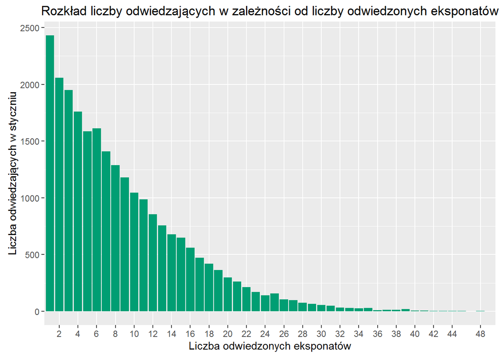

```r
# Ile przejść odwiedzający robili (liczba przejść = długość ścieżki-1)
liczba_eksponatow <- rowSums(wizyty_w[,-1])
dlugosc_sciezek <- as.data.frame(table(liczba_eksponatow))
ggplot(dlugosc_sciezek, aes(liczba_eksponatow, Freq)) + geom_bar(stat="identity", fill = "#009E73") + scale_y_continuous(name="Liczba odwiedzających w styczniu") + scale_x_discrete(name="Liczba odwiedzonych eksponatów", breaks=2*1:24) + ggtitle("Rozkład liczby odwiedzających w zależności od liczby odwiedzonych eksponatów")
```

Na wykresie widać, że przeważająca część zwiedzających wystawę Regeneracja obejrzała tylko kilka eksponatów, natomiast pojedynczy odwiedzający widzieli ich ponad 30.

Możemy również podejrzewać, że występuje zależność pomiędzy liczbą odwiedzonych eksponatów a średnim czasem interakcji z eksponatem. Na poniższym wykresie punktowym widać niewielką ujemną zależność pomiędzy tymi zmiennymi.

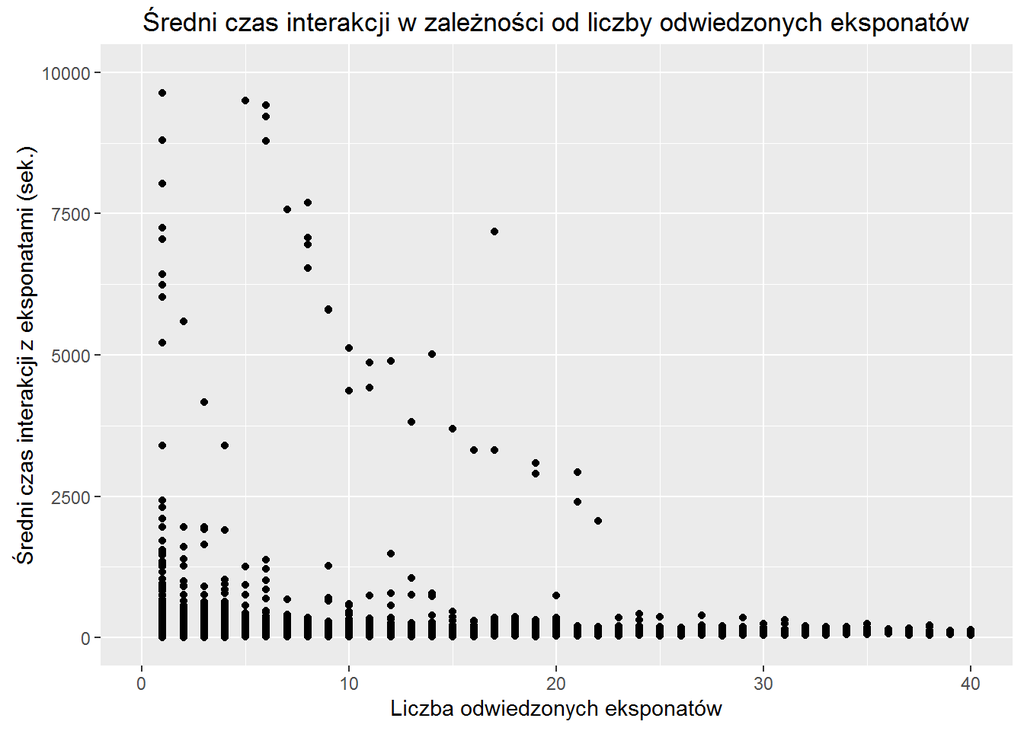

```r
ggplot(dane2, aes(liczba_eksponatow, czas_interakcji)) + geom_point() + xlim(0,40) + ylim(0,10000) + xlab("Liczba odwiedzonych eksponatów") + ylab("Średni czas interakcji z eksponatami (sek.)") + ggtitle("Średni czas interakcji w zależności od liczby odwiedzonych eksponatów")
```

### Uzupełnienia: analiza podścieżek

#### Najczęstrze podścieżki o długości czterech eksponatów

Następujący kod pozwolił nam zidentyfikować najczęstsze podścieżki o długości trzy i cztery eksponaty, które następnie zaznaczyłyśmy na odpowiedniej mapce w głównej analizie.

```r
podsciezki <- data_both[!is.na(data_both$przejscie), c("odwiedzajacy", "stacja", "przejscie")]
podsciezki$stacja <- as.character(podsciezki$stacja)
podsciezki$przejscie3 <- NA # podścieżki o długości 3
for(i in 2:nrow(podsciezki)){
    if(podsciezki$odwiedzajacy[i] == podsciezki$odwiedzajacy[i-1]){
        podsciezki$przejscie3[i] <- paste0(podsciezki$przejscie[i-1], paste0("->", podsciezki$stacja[i]))
    }
}
# Najczęstsze ścieżki o długości 3
x <- as.data.frame(table(podsciezki$przejscie3))
head(x[order(x$Freq, decreasing = TRUE), ], n=5)
```

```
##                        Var1 Freq
## 13134  cnk18->cnk78a->cnk23  394
## 3647  cnk06->cnk19a->cnk19b  262
## 15409   cnk21->cnk12->cnk20  209
## 8521   cnk12->cnk18->cnk78a  208
## 13419 cnk19a->cnk19b->cnk16  208
```

```r
podsciezki <- podsciezki[!is.na(podsciezki$przejscie3),]
podsciezki$przejscie4 <- NA # podścieżki o długości 4
for(i in 2:nrow(podsciezki)){
    if(podsciezki$odwiedzajacy[i] == podsciezki$odwiedzajacy[i-1]){
        podsciezki$przejscie4[i] <- paste0(podsciezki$przejscie3[i-1], paste0("->", podsciezki$stacja[i]))
    }
}
# Najczęstsze ścieżki o długości 4
x <- as.data.frame(table(podsciezki$przejscie4))
head(x[order(x$Freq, decreasing = TRUE), ], n=5)
```

```
##                                 Var1 Freq
## 35527    cnk18->cnk78a->cnk23->cnk62   79
## 18994 cnk100->cnk02b->cnk100->cnk02b   76
## 4118  cnk02b->cnk100->cnk02b->cnk100   72
## 23555    cnk12->cnk18->cnk78a->cnk23   67
## 35508    cnk18->cnk78a->cnk23->cnk26   63
```

#### Reguły asocjacji

Gdybyśmy nie wyłączyli wyjścia z tunelu strachów przed szukaniem reguł asocjacji dla wizyt, to otrzymalibyśmy następujący wykres zależności miar oceniających reguły (otrzymujemy bardzo dużo reguł obejmujących wejście i wyjście z tunelu strachów o bardzo wysokim podniesieniu).

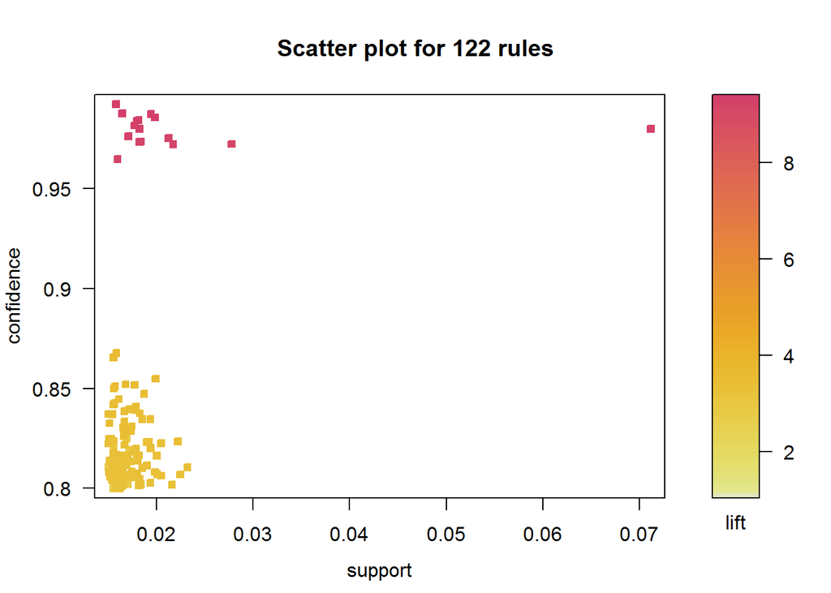

```r
# Tworzymy macierz wskazującą na odwiedzone stacje
wizyty_logi <- wizyty_w[,-1] > 0 # zaminiamy macierz na taką o wartościach logicznych
trans_wizyty2 <- as(wizyty_logi, "transactions") # zamieniamy na macierz transakcji
# tworzymy reguły asocjacji
rule3 <- apriori(trans_wizyty2, parameter = list(supp = 0.015), control = list(verbose = FALSE))
plot(rule3)
```

Oto wykres 10 najlepszych pod względem podniesienia reguł asocjacji przejść pomiędzy stacjami, zilustrowany na odpowiedniej mapce w głównej analizie.

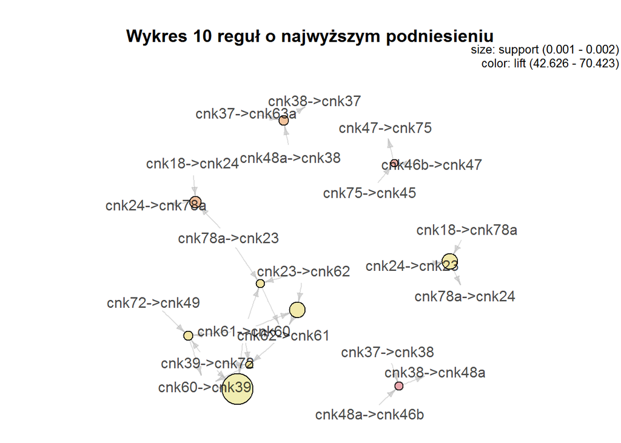

```r
plot(head(sort(rule2, by="lift"), n=10), method="graph", main="Wykres 10 reguł o najwyższym podniesieniu")
```

### Uzupełnienia: analiza kompletnych ścieżek

#### Kiedy odwiedzający odwiedzają co najmniej 10 eksponatów?

Poniżej przedstawiamy wyniki oszacowania parametrów regresji logistycznej objaśniającej prawdopodobieństwo zwiedzenia co najmniej 10 eksponatów średnim czasem interakcji z eksponatami oraz godziną i dniem tygodnia rozpoczęcia zwiedzania wystawy Regeneracja.

```r
logit <- glm(co_najmniej_10 ~ ., data = dane2[,-c(1:60,64)], family = "binomial")
summary(logit)
```

```
##
## Call:
## glm(formula = co_najmniej_10 ~ ., family = "binomial", data = dane2[,
##     -c(1:60, 64)])
##
## Deviance Residuals:
##     Min       1Q   Median       3Q      Max
## -1.2578  -0.9422  -0.8921   1.4035   1.9485
##
## Coefficients:
##                   Estimate Std. Error z value Pr(>|z|)
## (Intercept)      1.716e-03  1.131e-01   0.015 0.987891
## czas_interakcji -4.548e-05  3.300e-05  -1.378 0.168218
## godzina10       -9.278e-02  1.212e-01  -0.766 0.443954
## godzina11       -4.095e-01  1.162e-01  -3.525 0.000424 ***
## godzina12       -7.148e-01  1.153e-01  -6.198 5.72e-10 ***
## godzina13       -6.811e-01  1.162e-01  -5.863 4.54e-09 ***
## godzina14       -7.484e-01  1.157e-01  -6.468 9.91e-11 ***
## godzina15       -7.990e-01  1.162e-01  -6.876 6.15e-12 ***
## godzina16       -8.199e-01  1.175e-01  -6.980 2.95e-12 ***
## godzina17       -1.066e+00  1.248e-01  -8.540  < 2e-16 ***
## godzina18       -1.554e+00  1.760e-01  -8.833  < 2e-16 ***
## dzienśroda       1.678e-01  4.810e-02   3.489 0.000484 ***
## dzienczwartek    1.014e-01  4.701e-02   2.158 0.030942 *
## dzienpiątek      1.862e-01  4.520e-02   4.118 3.82e-05 ***
## dziensobota      1.194e-01  4.456e-02   2.681 0.007349 **
## dzienniedziela   1.664e-01  4.533e-02   3.672 0.000241 ***
## ---
## Signif. codes:  0 '***' 0.001 '**' 0.01 '*' 0.05 '.' 0.1 ' ' 1
##
## (Dispersion parameter for binomial family taken to be 1)
##
##     Null deviance: 31336  on 23909  degrees of freedom
## Residual deviance: 30974  on 23894  degrees of freedom
## AIC: 31006
##
## Number of Fisher Scoring iterations: 4
```

```r
dane2$logit_dopasowanie <- logit$fitted.values < 8686/(8686+15224)
confusionMatrix(dane2$logit_dopasowanie, dane2$co_najmniej_10)
```

```
## Confusion Matrix and Statistics
##
##           Reference
## Prediction FALSE  TRUE
##      FALSE  4875  3512
##      TRUE  10349  5174
##
##                Accuracy : 0.4203
##                  95% CI : (0.414, 0.4266)
##     No Information Rate : 0.6367
##     P-Value [Acc > NIR] : 1
##
##                   Kappa : -0.0719
##  Mcnemar's Test P-Value : <2e-16
##
##             Sensitivity : 0.3202
##             Specificity : 0.5957
##          Pos Pred Value : 0.5813
##          Neg Pred Value : 0.3333
##              Prevalence : 0.6367
##          Detection Rate : 0.2039
##    Detection Prevalence : 0.3508
##       Balanced Accuracy : 0.4579
##
##        'Positive' Class : FALSE
##
```

Oszacowania większości parametrów są istotne statystycznie, jednak model jest bardzo źle dopasowany do danych: model dobrze sklasyfikował zaledwie 42% obserwacji, przy czym model bazowy, przyporządkowujący obserwację zawsze do najliczniejszej kategorii klasyfikuje poprawnie ponad 63% obserwacji. Obie te miary dotyczą zbioru danych, na któryc model był szacowany (nie dzieliłyśmy próby na treningową i testową), więc dotyczą dopasowania do danych, a nie zdolności predykcyjnych.

#### Klasteryzacja

Poniżej przedstawiamy dendrogram metody Warda dla macierzy przejść, do którego odnosimy się w analizie wybierając liczbę klastrów.

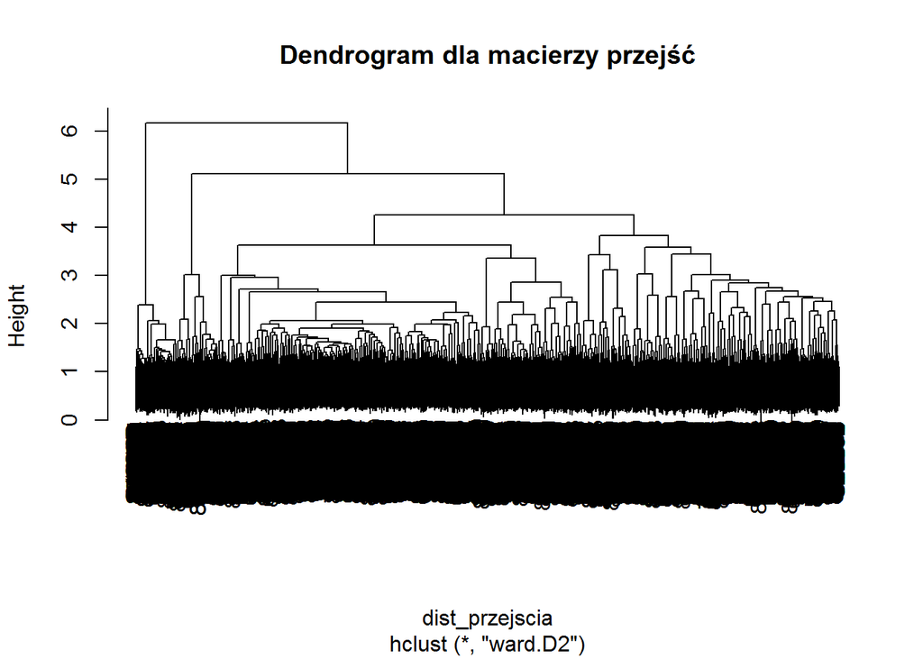

```r
cluster_przejscia <- hclust(dist_przejscia, method = "ward.D2")
plot(cluster_przejscia, main="Dendrogram dla macierzy przejść") # 3 albo 4
```

Oto sylwetki dwóch specyfikacji klasteryzacji dla macierzy przejść i podziału na trzy lub cztery klastry, odpowiednio.

```
##   cluster size ave.sil.width
## 1       1 2882          0.01
## 2       2 2043          0.00
## 3       3 3761          0.00
```

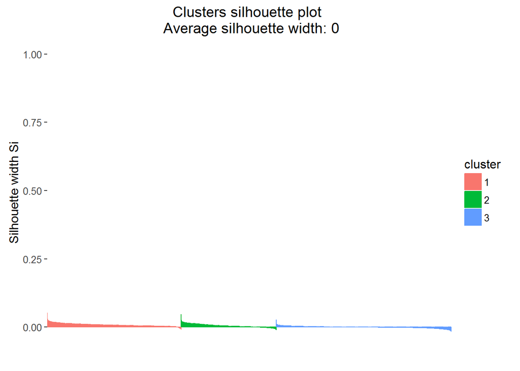

```r
syl_przejscia3 <- silhouette(cluster_przejscia3$clustering, dist_przejscia) # obliczamy sylwetki
fviz_silhouette(syl_przejscia3) # rysujemy wykres sylwetek
```

```
##   cluster size ave.sil.width
## 1       1 1760          0.01
## 2       2 1867          0.00
## 3       3 3159          0.00
## 4       4 1900          0.00
```

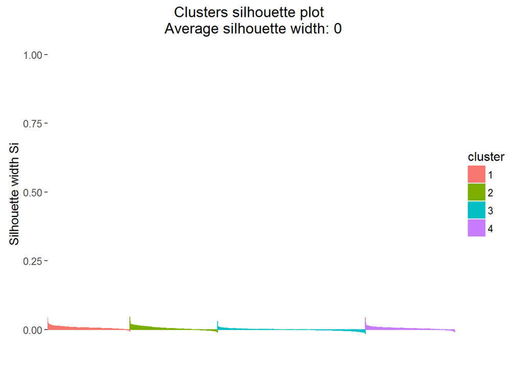

```r
syl_przejscia4 <- silhouette(cluster_przejscia4$clustering, dist_przejscia) # obliczamy sylwetki
fviz_silhouette(syl_przejscia4) # rysujemy wykres sylwetek
```

Poniższa mapka przestawia medoidy dla klasteryzacji na podstawie macierzy przejść.

```r
cluster_przejscia4$medoids # medoidy
```

```
## [1] "807831" "842260" "795765" "835034"
```

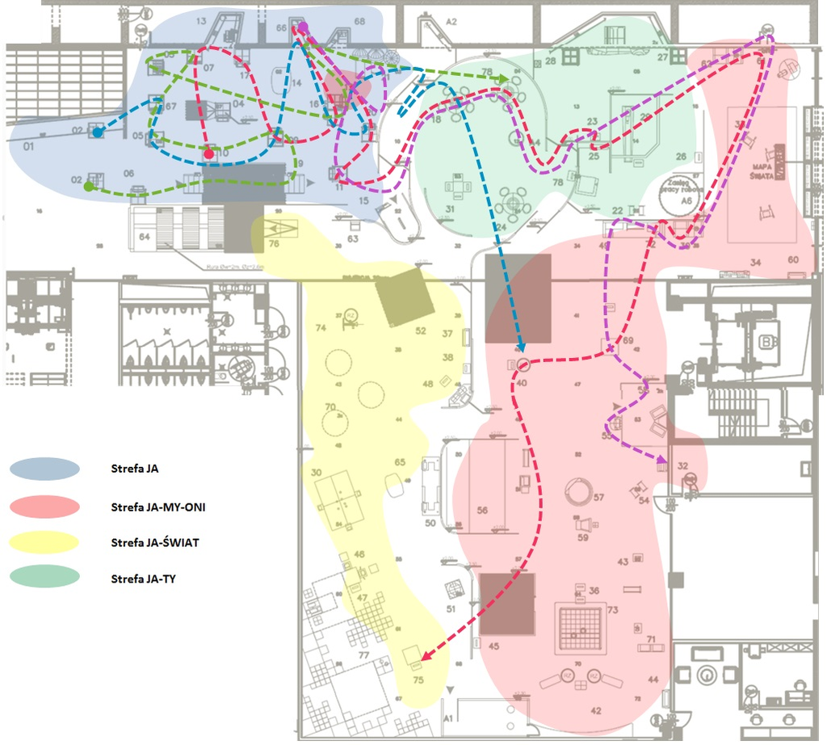

#### Klasteryzacja a rzutowanie na dwa wymiary

W tej części analizy rozważymy rzutowanie wielowymiarowych przestrzeni rozpiętych przez kolumny macierzy odległości na przestrzeń dwuwymiarową. Podejście umożliwia przedstawienie odwiedzających w podziale na klastry na wykresie. Najpierw dokonujemy rzutowania metodą CMD oraz ISO (ta druga nie pozwala na zerowe odległości w macierzy odległości, stąd do każdej komórki dodajemy mały epsilon).

```r
# Dla macierzy wizyt i podziału na 4 klastry
# trans1 <- as.data.frame(cmdscale(dist_wizyty, k=2))
load("faza3_wizyty_2d.rda")
# dist_wizyty_eps <- dist_wizyty + 0.001
# trans1iso <- as.data.frame(isoMDS(dist_wizyty_eps, k=2)[["points"]])
load("faza3_wizyty_2d_iso.rda")

# Dla macierzy przejść i podziału na 4 klastry
# trans2 <- as.data.frame(cmdscale(dist_przejscia, k=2))
load("faza3_przejscia_2d.rda.rda")
# dist_przejscia_eps <- dist_przejscia + 0.001
# trans2iso <- as.data.frame(isoMDS(dist_przejscia_eps, k=2)[["points"]])
load("faza3_przejscia_2d_iso.rda.rda")
```

Na potrzeby tej analizy podejście uwzględniające przejścia jest bardziej wartościowe, ponieważ rzutowanie macierzy na przestrzeń dwuwymiarową wyodrębnia wyraźne klastry (w nowej przestrzeni) w przypadku uwzględnienia macierzy przejść, co pozwoli na sensowną klasteryzację po tym rzutowaniu, która może okazać się wartościowa.

Następujące wykresy ilustrują podział na klastry po rzutowaniu macierzy odległości na przestrzeń dwuwymiarową. Widać, że w żadnym przypadku oprócz metody CMD dla macierzy przejść na wykresie nie widać grupowania obserwacji (oczywiście takie grupowanie może występować w przed rzutowaniem, ale tego nie jesteśmy w stanie zilustrować).

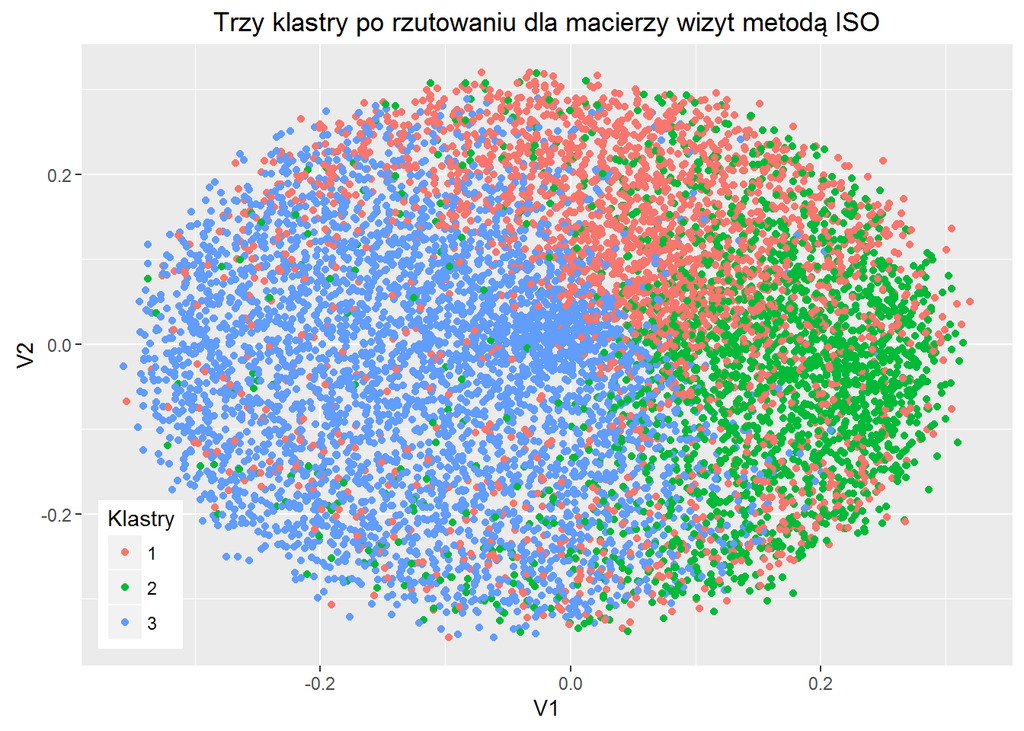

```r
# Dla macierzy wizyt i podziału na 3 klastry - Metoda ISO
trans1iso$klastry_przed <- cluster_wizyty3$clustering
ggplot(trans1iso, aes(V1, V2, color=factor(klastry_przed))) + geom_point() + theme(legend.justification=c(0,0), legend.position=c(0,0)) + scale_color_discrete(name = "Klastry") + ggtitle("Trzy klastry po rzutowaniu dla macierzy wizyt metodą ISO")
```

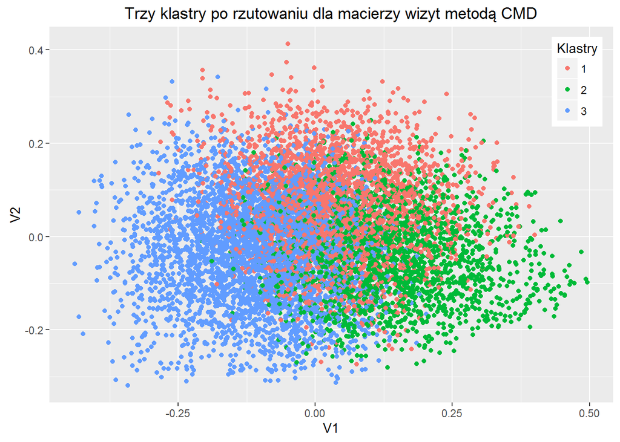

```r
# Dla macierzy wizyt i podziału na 3 klastry - Metoda CMD
trans1$klastry_przed <- cluster_wizyty3$clustering
ggplot(trans1, aes(V1, V2, color=factor(klastry_przed))) + geom_point() + theme(legend.justification=c(1,1), legend.position=c(1,1)) + scale_color_discrete(name = "Klastry") + ggtitle("Trzy klastry po rzutowaniu dla macierzy wizyt metodą CMD")
```

[figure not shown]

```r
# Dla macierzy przejść i podziału na 4 klastry - Metoda ISO
trans2iso$klastry_przed <- cluster_przejscia4$clustering
ggplot(trans2iso, aes(V1, V2, color=factor(klastry_przed))) + geom_point() + theme(legend.justification=c(0,0), legend.position=c(0,0)) + scale_color_discrete(name = "Klastry") + ggtitle("Trzy klastry po rzutowaniu dla macierzy przejść metodą ISO")
```

[figure not shown]

```r
# Dla macierzy przejść i podziału na 4 klastry - Metoda CMD
trans2$klastry_przed <- cluster_przejscia4$clustering
ggplot(trans2, aes(V1, V2, color=factor(klastry_przed))) + geom_point() + theme(legend.justification=c(0,0), legend.position=c(0,0)) + scale_color_discrete(name = "Klastry") + ggtitle("Trzy klastry po rzutowaniu dla macierzy przejść metodą CMD")
```

Na ostatnim wykresie widać, że po rzutowaniu odwiedzający dzielą się na trzy grupy: jedną skupioną, dwie podłużne i trochę obserwacji rozproszonych, natomiast podział na klastry w oryginalnej przestrzeni nie pokrywa się z nimi.

Dokonajmy zatem podziału na trzy klastry w nowej przestrzeni (zastosujemy odległość euklidesową gdyż odpowiada ona zwykłej odległości punktów w układzie współrzędnych).

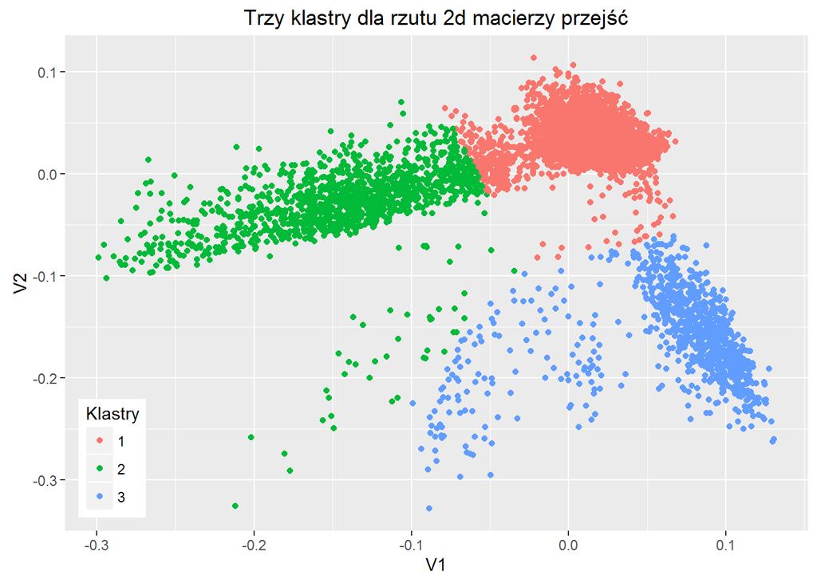

```r
dist_rzut <- daisy(trans2[,1:2]) # wyznaczamy macierz odległości euklidesowej
cluster_cmd3 <- pam(dist_rzut, k=3) # klasteryzacja
trans2$klastry_przed <- cluster_cmd3$clustering
ggplot(trans2, aes(V1, V2, color=factor(klastry_przed))) + geom_point() + theme(legend.justification=c(0,0), legend.position=c(0,0)) + scale_color_discrete(name = "Klastry") + ggtitle("Trzy klastry dla rzutu 2d macierzy przejść")
```

Na powyższym wykresie widać efekty klasteryzacji po rzutowaniu. Choć część klastra zielonego wydaje się być błędnie zaklasyfikowana do klastra różnowego poniższy wykres sylwetek pozwala stwierdzić, że ta klasteryzacja jest bardzo dobra (niemal nie występują wartości ujemne).

```
##   cluster size ave.sil.width
## 1       1 6441          0.81
## 2       2 1312          0.53
## 3       3  933          0.60
```

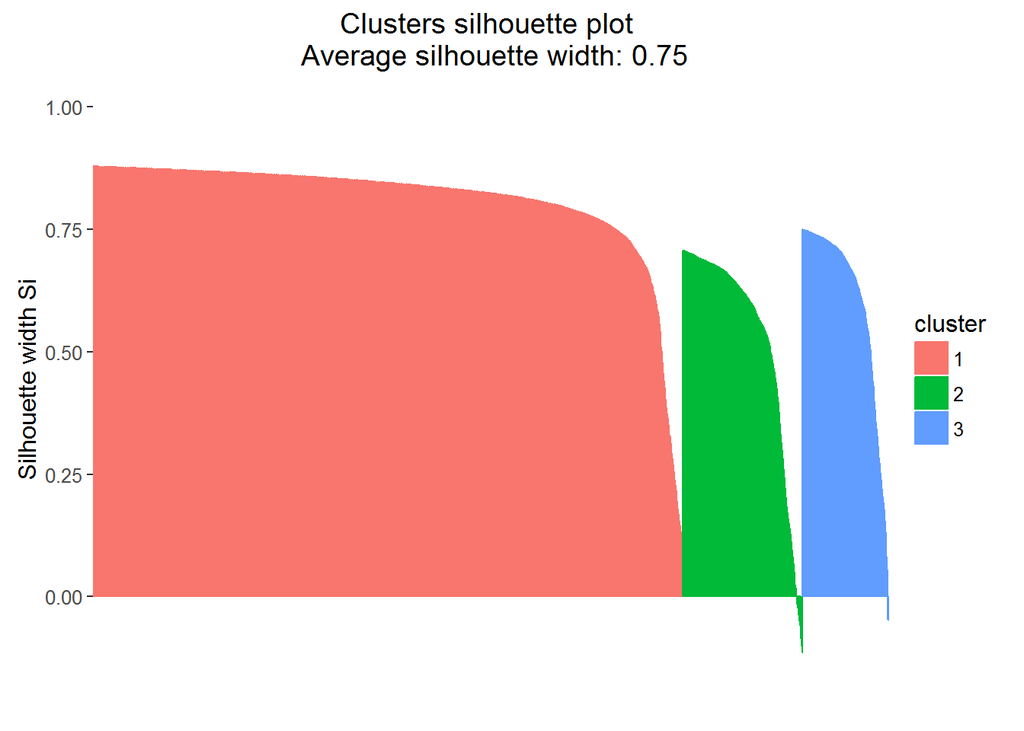

```r
syl_rzut <- silhouette(cluster_cmd3$clustering, dist_rzut) # obliczamy sylwetki
fviz_silhouette(syl_rzut) # rysujemy wykres sylwetek
```

Moglibyśmy uznać powyższą analizę za lepszą od klasteryzacji na oryginalnej przestrzeni jeśli wykonane rzutowanie dobrze zachowywałoby odległość. Aby to stwierdzić możemy stworzyć wykres typu `Shepard()`, na którym odległości w wyjściowej przestrzeni są porównanie do odległości w nowej przestrzeni. Dla idealnego rzutowania odległości w nowej przestrzeni byłyby równe odległościom w wyjściowej, czyli punkty na wykresie leżałyby na prostej x=y. W naszym przypadku sytuacja jest daleka od pożądanej:

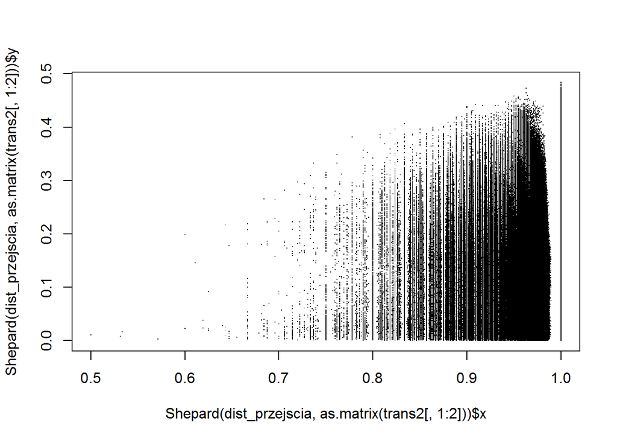

```r
plot(Shepard(dist_przejscia, as.matrix(trans2[,1:2])), pch=".")
```

Jak widać rzutowanie bardzo zmieniło odległości, co nie jest zaskakujące biorąc pod uwagę wymiar wyjściowej przestrzeni. Z tego względu stwierdzamy, że nie jest to dobre podejście i nie implementujemy go w głównej analizie.